# Index

1. **Introduction**: this will explain the project concept and motivation for the project (this can be based on your proposal). This must also state which project template you are using.
   - Motivations: Technology, Innovation, and Efficiency
   - Strengths
   - Restrictions
2. **Literature Review**: this is a revised version of the document that you submit for your second peer review.
   - Transformer
   - BERT
   - BART
   - RetNet
   - Neural Text Summarization: A Critical Evaluation
   - SAMSum Corpus: A Human-annotated Dialogue Dataset for Abstractive Summarization
   - Text Summarization with Pretrained Encoders
   - facebook/bart-large-cnn
   - google/pegasus-cnn_dailymail
   - Conclusion of Literature Review
3. **Design**: this is a revised version of the document that you submit for your third peer review.
   - Project Overview
   - Domain and Users
   - Structure of Project
   - Key Technologies and Methods
   - Work Plan
   - Evaluation Plan
4. **Implementation**: this should describe the implementation of the project. This should follow the style of the topic 6 peer review (but greatly expanded to cover the entire implementation), describing the major algorithms/techniques used, explanation of the most important parts of the code and a visual representation of the results (e.g. screenshots or graphs).
   - Preparation
   - Dataset
   - Baseline Model
   - Transformer Encoder-Decoder Model
   - Transformer Decoder-Only Model
   - BART Model
5. **Evaluation**: describe the evaluation carried out (e.g. user studies or testing on data) and give the results. This should give a critical evaluation of the project as a whole making clear successes, failures, limitations and possible extensions.
   - Performance Difference
   - Hypothesis Verification
   - Hyperparameters
   - Model Size
   - Training Time
   - Prediction Time
6. **Conclusion**: This can be a short summary of the project as a whole but it can also bring out any broader themes you would like to discuss or suggest further work.
   - Future Research
   - Reflecting on the Development Process
   - Ethical Consideration

## Word Count

| ___ | count | limit |
| --- | --- | --- |
| Total | 9081 | 9500 |
| Introduction | 673 | 1000 |
| Literature Review | 2068 | 2500 |
| Design | 1865 | 2000 |
| Implementation | 1995 | 2000 |
| Evaluation | 1492 | 1500 |
| Conclusion | 988 | 1000 |

## GitHub Repository

- https://github.com/justoneplanet/cm3070final

# Introduction

I have chosen the "Deep Learning on a public dataset" template from the Machine Learning and Neural Networks course (CM3015). I use public datasets, such as SAMSum and CNN dailymail datasets, to build a text summarization model in this project. The task of text summarization means generating a short organized summary from a long article, such as news, by extracting and abstracting it. The role of text summarization is crucial in various applications, such as news aggregation and academic research. It is a challenging task due to the necessity to identify the most essential information in a text, preserving its coherence and meaning.

This is a research project in which I investigate recent trends and deepen my knowledge of Deep Learning, which goes beyond the contents of CM3015, and a text summarization model is eventually built.

In addition, this project supposes that an organization or a group is the user, such as a (web) system development company with little machine-learning knowledge. Therefore, the deliverable report must be scientific and convincing to explain why each parameter is adopted and be knowledgeable for its developers. The deliverable code and model must run quickly on standard devices like a web server. On the other hand, mobile devices might be unable to run the large model because they have a smaller amount of memory.

## Motivations: Technology, Innovation, and Efficiency

### Technology

In preparation for vector calculation and vector transformation, their representation of text is the key to processing. Various types of text representations and neural network models have been developed in recent years, especially since the Transformer model was invented. Aside from the one-hot encoding introduced in CM3015, I am going to use techniques, such as text embedding, positional embedding, and BERT, that can appropriately handle the meanings of each word. The neural network is vector transformations. It is worth investigating how well each representation of embedding layers can capture the characteristics of text data.

### Innovation

The Transformer is one of the most common and game-changing models for sequential data, such as text. In addition, it is also used in text-to-image generative artificial intelligence (AI), large language models (LLM), and so on. Many derived models based on the Transformer architecture, such as BERT, outperform others in natural language processing. [10] Another model based on the Transformer, named Vision Transformer, has recently been used for image recognition tasks to overcome Convolutional Neural Network's (CNN) weaknesses. [9] Moreover, there is a more efficient model based on the Transformer model called the Retentive Network. Because all these architectures are based on the Transformer model, deepening its knowledge leads to understanding whole machine learning. Additionally, even in the future, many new architectures based on the Transformer models will be released.

### Efficiency and Ecology

Measuring the performances of various models is one of the exciting and essential points.

Advanced models do not always achieve the best performance. For example, when the Recurrent Neural Network model, which is one of the advanced models, is used for a text classification task, even though it does not always work better than a dense model, it mostly consumes more computing resources. [11] That is, it completely wastes resources. I will analyze each model's strengths and weaknesses in terms of practical uses.

As recent investigations indicate, building LLM models indirectly emits a significant amount of CO2. Investigating efficiency that leads to the ecology is socially meaningful, even in the environmental aspect. However, since there are insufficient computing resources to build an LLM model, this project does not target building an LLM.

## Strengths

- The model is developed through practical experimentation.
- The advantages of the model are represented not only numerically but also visually.
- In the process, the neural networks and deep learning knowledge is deepened.

## Restrictions

- The restriction of local machine power, which is mainly used in the experimental environment, makes it impossible to examine the large, complex neural network.
- For the time constraints, some models, such as the recurrent neural network (RNN), which is used to compare with the Transformer model, are not investigated to the maximum.

# Literature Review

I aim to explore the current understanding of machine learning model architectures and their performances, focusing on the key technology "Transformer". Moreover, in this project, I investigate the effectiveness of the Transformer and finally build a text summarization model. Specifically, the following items were reviewed. The following bold items did not exist in the preliminary report and were added to the final report.

- Transformer
- **BERT**
- **BART**
- RetNet
- Neural Text Summarization: A Critical Evaluation
- **ROUGE: A Package for Automatic Evaluation of Summaries**
- **SAMSum Corpus: A Human-annotated Dialogue Dataset for Abstractive Summarization**
- Text Summarization with Pretrained Encoders
- facebook/bart-large-cnn
- google/pegasus-cnn_dailymail

## Transformer

Vaswani et al. (2017) proposed a new simple architecture, named Transformer, based on attention mechanisms without recurrence and convolutions. [1]

The architecture of the Transformer, which consists of both encoders and decoders, is introduced with a simple figure.

The paper indicates the algorithms and architecture of the Transformer with formulas, comparing the former architectures, such as the recurrent neural network model and the gate recurrent unit model. How to reduce the amount of calculation for longer input sequences, which is one of the defects, is also introduced kindly. However, because of the nature of the paper, concrete implementation is not shown. Instead, it provides a link to a GitHub repository, "tensor2tensor," [2] where some implementations with Python code are introduced. Additionally, since the owner has not updated the repository, it is unclear whether they can run it on the current Python environment.

In addition, because the Transformer was initially developed for the machine translation task, various tasks except translation are not mentioned in this paper, which was written in 2017. Thereby, the effectiveness of the Transformer has not been investigated for a wide range of NLP tasks here.

As mentioned initially, hyperparameter tunings are obviously required to investigate effectiveness. The section "6.2 Model Variations" describes the parameters such as the number of heads, the parameters of the optimizer, and so on that exist in the Transformer model, and the same indicators will be used to compare the performance in this project. The experiment environment, which the paper disclosed, is useful to the experiments in this project.

I have obtained the following beneficial knowledge, even though it is not directly related to my project.

- The number of heads is neither too many nor too few
- Interpretable models

The paper does not include the following items, which are required for this project.

- Sufficient benchmarks for various NLP tasks/applications
- Minimum viable and runnable code in the modern environment

## BERT

Devlin, J. et al. (2018) introduced a new language representation model Bidirectional Encoder Representations from Transformers (BERT) that can be fine-tuned with one additional output layer for various tasks. [10]

- BERT uses masked language models to enable pre-trained deep bidirectional representations, not unidirectional.
- The "Bidirectional" indicates that the BERT processes sequences not only from left to right but also right to left.
- A distinctive feature of BERT is its unified architecture across different tasks.

The following new trainings/features are used in BERT.

- Masked language model
- Next sentence prediction

We have to consider the following points:

> For $BERT_{LARGE}$ we found that finetuning was sometimes unstable on small datasets.

Finally, the effectiveness and necessity of pre-training and transfer learning have been shown in this paper. It is indicated that these techniques are essential for computationally or quantitatively fewer resources and are applicable to a wide range of NLP tasks.

## BART

Lewis, M. et al. (2019) presented BART, a denoising autoencoder for pre-training sequence-to-sequence models. [23] BART is simply expressed as a combined model with the following parts;

- BEAT
- Autoregressive decoder

The following diagram, described in the paper, depicts the primary architectures of BART.

[figure not shown]

Lewis, M. et al. (2019). BART: Denoising Sequence-to-Sequence Pre-training for Natural Language Generation, Translation, and Comprehension. [23]

Re-implemented pre-training approaches are introduced as follows.

- Language Model: Training next words left-to-right.
- Permuted Language Model: Generating sampled 1/6 of the tokens in a random order.
- Masked Language Model: As with the BERT model, 15% of tokens are masked and predicted.
- Multitask Masked Language Model: Besides GPT left-to-right and BERT random masks, various masks were added, including right-to-left.
- Masked Seq-to-Seq: masked 50% of tokens of a span, trained a Seq-to-Seq model, and predicted them.

The following tasks/datasets are used to compare the performances of each pre-training.

- SQuAD: extractive question-answering task on Wikipedia paragraphs.
- MNLI: a bitext classification task to predict whether one sentence entails another.
- ELI5: answering task for a long-form abstractive question.
- XSum: news text summarization task
- ConvAI2: dialogue text generation task
- CNN/DM: text summarization task

## RetNet

Yutao et al. (2023) proposed the Retentive Network (RetNet), which is a strong successor to Transformer for large language models.[3]

One of the drawbacks of the Transformer, which is introduced in this paper, is the slow inference and inefficiency due to multi-head attention. The performance comparison between the RetNet and the Transformer has been executed for large language models and represents the improvement. They are executed and compared for large language models, and that difference might not be remarkable for smaller models such as text summarization tasks.

The section "3 Experiments" mentions the following:

> Perplexity decreases along with scaling up the model size. We empirically observe that RetNet tends to outperform Transformer when the model size is larger than 2B. [3]

The section "3.3 Training Cost" shows the specific environment where the evaluation of this paper was executed as follows.

> We evaluate the results with eight Nvidia A100-80GB GPUs, because FlashAttention is highly optimized for A100. Tensor parallelism is enabled for 6.7B and 13B models. [3]

Building a text summarization model in this project is mainly executed on the local macOS machine, which has an Apple Silicon M2 CPU, which has a significantly different architecture from Nvidia GPUs.

> Moreover, without relying on specific kernels, it is easy to train RetNet on other platforms efficiently. For example, we train the RetNet models on an AMD MI200 cluster with decent throughput. It is notable that RetNet has the potential to further reduce cost via advanced implementation, such as kernel fusion. [3]

Even though the above quote mentioned the performance on the other device, the environment is highly parallelized, and it is uncertain if this project can derive beneficial knowledge through experimental comparisons.

Though this does not matter directly to this project, as the sections "2.3 Overall Architecture of Retention Networks" and "3.4 Inference Cost" mention, the inference cost of the RetNet model is remarkably $O(1)$. [3] When a quick response for longer sequences/tokens is required, the RetNet model can be one of the realistic choices.

## Neural Text Summarization: A Critical Evaluation

Wojciech et al. (2019) introduced and evaluated the current shortcomings of text summarization.[4] The methodology of the evaluation should be notable in this paper. The previously introduced two papers are not for text summarization tasks, and the BLEU metric is used, which is for the evaluation of translation task performance. This is not for summarization tasks. Though loss values probably evaluate the performances, they cannot clearly consider sentences' structures for evaluations. Therefore, following this paper, the ROUGE metric is used in this project. Fortunately, KerasNLP has the following two metrics as standard.

- [ROUGE-N](https://keras.io/api/keras_nlp/metrics/rouge_n/)
- [ROUGE-L](https://keras.io/api/keras_nlp/metrics/rouge_l/)

Note that the ROUGE-N metric uses n-gram to refer to the overlap, and the ROUGE-L metric uses the longest common subsequence that can detect the sentence level structure. [8]

Though the following does not matter directly, some shortcomings of the current summarization model are introduced here.

- A summarization task depends on the reader's expectations and prior knowledge. However, the current models are not provided with additional information.
- Although the ROUGE metric is widely used, it does not factually and consistently examine summarized text, but just lexically.
- The bias and diversity of the dataset.

## ROUGE: A Package for Automatic Evaluation of Summaries

Chin-Yew Lin suggested the Recall-Oriented Understudy for Gisting Evaluation (ROUGE) to measure the quality of a summary text. [24] Though, human judgments were traditionally used for the evaluation of the text summarization quality; it was time-consuming and costly even for simple manual evaluation, and it is impossible to be frequently executed. ROUGE is one of the methods, which correlates to human judgments, to programmatically measure the quality of summarized text. The equation is introduced as follows;

> $ROUGE-N = \frac{\sum_{S∈ReferenceSummaries}\sum_{gram_n∈S}Count_{match}(gram_n)}{\sum_{S∈(ReferenceSummaries)\sum_{gram_n∈S}Count(gram_n)}}$  
> [24]

That is, matching of n-gram is used to evaluate the quality.

## SAMSum Corpus: A Human-annotated Dialogue Dataset for Abstractive Summarization

Bogdan Gliwa et al. introduced the SAMSum Corpus, which is an abstractive dialogue summary. [25] The paper shows that dedicated models and non-standard evaluations are required for an abstractive dialogue summarization.

## Text Summarization with Pretrained Encoders

Yang et al. (2019) indicated the effectiveness of the BERT, which is an abbreviation of Bidirectional Encoder Representations from Transformers, for text summarization, which is one of the NLP tasks. [5]

In this paper, the Bidirectional Encoder Representations from Transformers(BERT) model, where a pre-trained model and a scratch model are combined, is compared with other typical models for text summarization tasks, and it is concluded that the BERT model outperformed others. However, it seems slightly unclear whether the pre-trained model actually works better because there is not a comparison of the same architecture model between pre-trained and scratch.

As the section "Introduction" mentions, the BERT model, one of the Transformer models, has affected word and sentence representation. Thus, this model may become a research target in this project.

> When fine-tuning for a specific task, unlike ELMo whose parameters are usually fixed, parameters in BERT are jointly fine-tuned with additional task- specific parameters. [5]

Whereas, as the above is written, since the pre-trained BERT model goes through the fine-tuning phase, it might take longer time for training than fixed parameters' models such as word2vec and GloVe.

The table of the section "3.3 Abstractive Summarization" holds the various types of datasets. Though this might not matter to the paper, apart from CNN DailyMail, NYT, and XSum are used as the datasets. In this project, the CNN dailymail will be utilized as a dataset. However, they are kept as sub plans, preparing for unexpected situations.

> Each token $w_i$ is assigned three kinds of embeddings: token embeddings indicate the meaning of each token, segmentation embeddings are used to discriminate between two sentences (e.g., during a sentence-pair classification task) and position embeddings indicate the position of each token within the text sequence. [5]

If the BERT model is used, differences in embeddings must be addressed.

## facebook/bart-large-cnn

This is a text summarization model developed by Facebook that is available on Hugging Face. [19]

Particularly noteworthy is the model size and its performance. The model size, the number of parameters, is 406M, and the results of ROUGE-1, ROUGE-2, and ROUGE-L are 42.949, 20.815, and 30.619 respectively.

In addition, pre-trained BART is used in this text summarization model.

> BART is a transformer encoder-encoder (seq2seq) model with a bidirectional (BERT-like) encoder and an autoregressive (GPT-like) decoder. BART is pre-trained by (1) corrupting text with an arbitrary noising function, and (2) learning a model to reconstruct the original text. [19]

> BART is particularly effective when fine-tuned for text generation (e.g. summarization, translation) but also works well for comprehension tasks (e.g. text classification, question answering). This particular checkpoint has been fine-tuned on CNN Daily Mail, a large collection of text-summary pairs. [19]

The concrete specifications are as follows. [19]

| Parameter | Value |
| --- | --- |
| Self-attention heads | 16 |
| Encoder layers | 12 |
| Feed forward network dim | 4096 |
| Dropout | 0.1 |
| Max length | 142 |
| Max position emneddings | 1024 |
| Min length | 56 |

## google/pegasus-cnn_dailymail

This is another text summarization model developed by Google that is available on Hugging Face. [20]

This model has been trained not only with the CNN dailymail dataset but also with many others. It has 568M parameters and consists of 12 Transformer encoder layers and 12 Transformer decoder layers. The sinusoidal method is used for the positional embedding. The number of vocabulary is 50265.

In addition, the paper "PEGASUS: Pre-training with Extracted Gap-sentences for Abstractive Summarization" shows that the results of ROUGE-1, ROUGE-2, and ROUGE-L are 44.16, 21.56, and 41.30 respectively. [21]

The concrete specifications of the Pegasus base model are as follows. [21]

| Parameter | Value |
| --- | --- |
| Self-attention heads | 12 |
| Encoder layers | 12 |
| Feed forward network dim | 3072 |

## Conclusion of Literature Review

In conclusion, the superiority and effectiveness of the Transformer and its self-attention have been shown compared with other architectures, such as the recurrent neural network and convolutional neural network. However, performances, tunings, other NLP tasks, and architectures that determine if encoders and/or decoders are used have not been shown. And that is what I aim to do.

I have slightly changed my mind while reading papers. Specifically, instead of regarding the RetNet model as the main topic, hyperparameter tunings of the Transformer model are going to be mainly researched. The RetNet model will be researched optionally. The reason is as follows.

- The RetNet paper shows that it is effective only for large language models.
- The experiments on the ResNet paper were executed on the highly parallelized environment, which is different from the local machine that is used in this project.
- The training to build a text summarization model takes a considerable amount of time.

Therefore, because a beneficial report may not be provided if most resources are invested in experiments with little chance of seeing differences, I am going to make the experiment about the RetNet model optional. Instead, clearly beneficial hyperparameter tunings are executed in the first half to ensure users' benefits.

Moreover, the comparison between the pre-trained models and non-pre-trained models will also be one of the interesting topics.

Finally, it might be very difficult to self-build a text summarization model and mark a better score of ROUGE metrics on the current local machine because the models of Google and Facebook are trained with a number of layers and parameters using high computational GPUs. However, it might be possible to build a smaller model that is beneficial for a specific environment. Since KerasNLP provides an easy way to use Bidirectional Autoregressive Transformer (BART), the performance might be able to get close to the Google or Facebook results if it is used. [22]

# Design

## Project Overview

I have chosen the template "Deep Learning on a public dataset" of CM3015 "Machine Learning and Neural Networks". In this project, I build a text summarization model with public datasets, such as the SAMSum corpus and the Cable News Network(CNN) dailymail datasets.

Unlike other templates of other courses, the deliverables are the machine learning model and its documents, and this project does not have user interfaces for end users. However, I assume to deliver the machine learning model to an organization that has a plan where the text summarization model is integrated into a system, which has actual end users.

There is also the aspect of a research project where I investigate recent trends and deepen my knowledge of Deep Learning that was not sufficiently covered in the CM3015 course. Day by day and month by month, the field and market of deep learning technology for natural language processing is rapidly growing. Consequently, the deliverable document is beneficial for developers.

## Domain and Users

As I mentioned above, unlike other project templates, the project template on CM3015 does not have a specific user. However, since it is difficult to determine what is beneficial and how beneficial a feature is without specific users, I assume that users are developers outside the organization who want to install a machine learning feature and model into a currently running system, as follows.

Specifically, they are not familiar with deep learning but with Python server-side applications. They want to adopt a text summarization feature into a current running system. My job is solving the problem and providing text summarization models and their knowledgeable and beneficial documents to them.

### Justify features based on domain and users

Firstly, end users do not notice if a model is highly advanced or not. Instead, they mind the time and performance of response.

#### Why is the Transformer model used?

In this project, text summarization models are built. The neural network model is trained with input sequences to output other sequences as summarized text. The Transformer model is superior to the dense model in processing sequence data, so it is used for the text summarization model.

On text classification tasks, well-tuned dense layer models overcome advanced models, such as a Transformer model, a Recurrent Neural Network (RNN) model and so on, under certain conditions.

However, text generation tasks, such as text summarization, could not achieve satisfactory outcomes for a long time. Encoder-decoder models, text embeddings, and Transformers, which can handle sequences well, have made them possible. That is why the Transformer model is used.

#### Why is hyperparameter tuning necessary?

There are a number of hyperparameters in a neural network model, and there does not exist a formula that can derive optimized their values. They depend on each dataset and architecture. The best parameter set must be found with hyperparameter tunings.

Prior to testing advanced models, the hyperparameter tunings should be executed sufficiently. Even if an advanced model such as RetNet outperforms a traditional model, it is impossible to compare the advanced model and the traditional model fairly without hyperparameter tunings.

Fairly comparisons derive better models that are beneficial for users. That is the reason why hyperparameter tunings are necessary.

#### Why is the RetNet model reseached optionally?

Optionally, the other cutting-edge models, such as the RetNet model, are examined. Generally, end users do not mind if a model is highly advanced model or not. Instead, they mind the time and performance of response. Whereas, it might be able to efficiently use resources, and that might lead to the reduction of the cost for users. This is one of the reason why the research of the RetNet model is made optional.

#### Which dataset is mainly used?

In this reseach, the following datasets are compared to choose one of them to build a model. These datasets have been mainly from the TensorFlow datasets catalog since this project adopted TensorFlow. [26] (Some of the following datasets were not able to be accessed with the TensorFlow datasets library with DownloadError.)

| __ | dataset/download size | max sequence length (75%-covered) |
| --- | --- | --- |
| cnn_dailymail | 1.29 GiB | 2347/1296 (877/60) |
| big_patent | 9.45 GiB | - |
| newsroom | 5.13 GiB | - |
| reddit | 18.09 GiB | - |
| scientific_papers | 4.20 GiB | - |
| aeslc | 14.96 MiB | 3136/15 (131/5) |
| billsum | 260.84 MiB | 3055/808 (1644/240) |
| booksum | - | - |
| databricks_dolly | 12.69 MiB | - |
| samsum | 10.71 MiB | 803/64 (128/27) |

Initially, I chose the cnn_dailymail dataset because the size is sufficient for for training, it is widely known as a news media, it is generally used in text summarization researches, and it can be downloaded even on the Kaggle website. Then, I implemented the prototype text summarization model. It was supposed that experiments would go well.

However, when I tried to increase the encoder/decoder sequence size or the vocabulary size, the training phase exhausted the RAM, and the out-of-memory error was sometimes caused, even though the local environment had 32GB RAM. That is, the local experiment environment did not satisfy the minimum requirement with this dataset size.

As a result, I must have changed the dataset into a smaller one, and the samsum dataset, which was the smallest, was the best choice. This dataset, which was published by Samsung Research and Development, is one of the most reliable datasets. The reasons to be chosen this dataset are summarized as follows:

- It can be downloaded even on the Kaggle website.
- It is sufficiently small for the local development environment.
- It is widely used in text summarization researches.
- It is one of the reliable datasets.

## Structure of Project

The report outline is as follows:

- Introduction
- Literature Review
- Design
- Implementation
  - Preparation
  - Dataset
  - Baseline Model
  - Transformer Encoder-Decoder Model
  - Transformer Decoder-Only Model
  - BART Model
- Evaluation
- Conclusion

This project's main deliverable is a model for the text summarization task and its Jupiter notebook document.

The model is derived through comparisons and experiments, mainly in the "Implementation" and "Evaluation" sections. Specifically, in this project, the 4 models, which are an RNN model, a Transformer encoder-decoder model, a Transformer decoder-only model, and a BART model, are developed to identify the best/better text summarization model. The Transformer encoder-decoder model, the original architecture of the Transformer model, is chosen to deepen the knowledge of the Transformer, which was mentioned in the "Introduction" section. The reason why the other 3 models have been chosen is as follows:

- RNN Model (Baseline): This model was generally used before the Transformer model displaced it. The advantages and differences of the Transformer model are revealed.
- Transformer Decoder-Only Model: Another architecture for generative tasks of the Transformer model. The best choice for the text summarization task is identified.
- BART Model: A pre-trained model. The effectiveness and its basis of the pre-training are represented.

Additionally, the model is provided with minimum viable code to run it. Multiple models are possibly provided because the difference in the size of each model affects the machine's requirements where it runs.

## Key Technologies and Methods

I introduce libraries and technologies here. To be correct and objective, I explain them in my own words as little as possible, citing public documents, and websites. Instead, I explain how each technology and library is used in my own words for the project.

#### TensorFlow

This is a machine learning library, which is mainly used in this project.

> An end-to-end open source machine learning platform for everyone. Discover TensorFlow's flexible ecosystem of tools, libraries and community resources. [12]

In this project, the TensorFlow library is used not only for building text summarization models but also for most other tasks from the beginning to the end.

#### TensorBoard

This is a visualization tool for machine learning program such as TensorFlow and PyTorch. This is used to visualize Transformer models and debug them.

#### Keras

This is an OSS neural network library. It depends on the library version, it can switch TensorFlow to other machine learning library.

> Keras is an API designed for human beings, not machines. Keras follows best practices for reducing cognitive load: it offers consistent & simple APIs, it minimizes the number of user actions required for common use cases, and it provides clear & actionable error messages. Keras also gives the highest priority to crafting great documentation and developer guides. [13]

This library is used throughout the whole project to manipulate the TensorFlow library.

#### KerasNLP

> KerasNLP is a natural language processing library that works natively with TensorFlow, JAX, or PyTorch. Built on Keras 3, these models, layers, metrics, and tokenizers can be trained and serialized in any framework and re-used in another without costly migrations. [14]

In this project, the Transformer model, which consists of the Transformer encoder layer and the Transformer decoder layer, is used to build text summarization models. It is possible to self-implement them by following the paper and books. However, it might unintentionally include bugs. Then, the model and its documents lose the reliability for readers. Therefore, the KerasNLP, which is a part of the widely known library "Keras" and contains the Transformer layer classes, is utilized here to secure the reliability.

Moreover, a lot of hyperparameter tunings are executed in this project. Their classes in KerasNLP is well-architected so that hyperparameters are easily injected to each layer. This is another reason why the KerasNLP is used here.

#### PyTorch

This is another OSS machine learning library. PyTorch is featured with the following characteristics according to the official website.

> **Production Ready**  
> Transition seamlessly between eager and graph modes with TorchScript, and accelerate the path to production with TorchServe.  
> **Distributed Training**  
> Scalable distributed training and performance optimization in research and production is enabled by the torch.distributed backend.  
> **Robust Ecosystem**  
> A rich ecosystem of tools and libraries extends PyTorch and supports development in computer vision, NLP and more.  
> **Cloud Support**  
> PyTorch is well supported on major cloud platforms, providing frictionless development and easy scaling.  
> [15]

It is not directly used for the project development. However, some text summarization models that I have introduced has been developed with this PyTorch library.

#### Transformers

This is a software library of Hugging Face, Inc. The official repository of GitHub introduces as follows.

> Transformers provides thousands of pretrained models to perform tasks on different modalities such as text, vision, and audio. [16]

> Transformers provides APIs to quickly download and use those pretrained models on a given text, fine-tune them on your own datasets and then share them with the community on our model hub. At the same time, each python module defining an architecture is fully standalone and can be modified to enable quick research experiments. [16]

> Transformers is backed by the three most popular deep learning libraries — Jax, PyTorch and TensorFlow — with a seamless integration between them. It's straightforward to train your models with one before loading them for inference with the other. [16]

I have investigated the following 2 text summarization models as a part of competitive research.

- facebook/bart-large-cnn [17]
- google/pegasus-cnn_dailymail [18]

They are distributed through huggingface and the Transformers library is necessary to use these models.

## Work Plan

The first 2 to 3 weeks are used to develop the Transformer encoder-decoder model. Its part of the document is written at the same time. After that, hyperparameter tunings are repeatedly executed with small cycles so that they are efficient. The uncertainty of this phase is the length of training time. The optional implementation for the RetNet model keeps aside the time of 3 weeks. At last, there is a time for the documentation and the buffer.

[figure not shown]

Figure 3.1: Schedule

## Evaluation Plan

Normal testing, which is for machine learning models, and hypothesis verification are executed to evaluate the project. However, the human tester is not used to check performance because it is difficult to organize the tester team for this project free of charge.

### Testing

The following metrics are used to evaluate model performances with the test dataset.

- Loss
- Accuracy
- ROUGE-N
  - ROUGE-1
  - ROUGE-2
- ROUGE-L

The subject models are as follows:

- RNN Model (Baseline)
- Transformer Encoder-Decoder Model
- Transformer Decoder-Only Model
- BART Model

First, the baseline model is built and evaluated. Next, the Transformer encoder-decoder model is built, evaluated, and compared with the baseline to numerically present how better a generated model is. The Transformer decoder-only model is built and compared with the Transformer encoder-decoder model. Finally, the BART model is compared.

### Verification of Hypotheses

Additionally, the following hypotheses are verified.

- Hyperparameter tunings are significantly effective even on a Transformer model.
- Transformer models can generate text more sophisticatedly than dense layer models.
- The encoder-decoder model of the Transformer works better for text summarization tasks than the only-decoder model.
- Pre-trained models improve the text summarization performance.

The following hypothesis is verified as a result of an optional implementation, if possible.

- The RetNet architecture for a small model does not make a difference.

Whereas, it is seemingly difficult to verify the following hypotheses in this project, even though they are interesting topics. The first one is a thought during the prototype implementation. A huge Transformer model is essential to verify the first hypothesis, and the current local environment can't run. Moreover, as far as I have read several papers, no one has solved the second one. That is, the task of text summarization is strongly related to human prior knowledge and understanding of the things that are summarized. Thus, I am going to temporarily exclude them from the project verification.

- An excessive number of units and layers for the number of dataset entries overfits.
- Prior knowledge and bias cannot be solved on the current architecture.

# Implementation

## Preparation

When this project started, the `tensorflow-text` library did not support Apple Silicon, the local environment's processor, until TensorFlow version 2.17.0 started to support it on Jul 10, 2024. So, the TensorFlow version 2.16.2 was initially used and upgraded to 2.17.0 later.

The `keras` library is used to build neural network models with the TensorFlow backend and the `keras-nlp` is installed to use Transformer classes without self-implementation. ROUGE is one of the metrics in this report, and it is calculated using the `keras-nlp` that is dependent on the `rouge-score` library.

The `tensorflow-datasets` and `datasets` libraries are used to download public datasets, such as the SAMSum and CNN/Daily Mail datasets, and convert them to the TensorFlow dataset object. Additionally, the `py7zr` library is required for the SAMSum dataset.

```python
# For Apple Silicon mac OS
# %pip install -U tensorflow==2.17.0 tensorflow-datasets tensorflow-text tensorflow-macos keras==3.4.1 keras-nlp datasets rouge-score
# For Intel mac
# %pip install -U tensorflow==2.17.0 tensorflow-datasets tensorflow-text keras==3.4.1 keras-nlp datasets rouge-score
# For AWS SageMaker
# %pip install -U packaging setuptools
# %pip install -U tensorflow==2.17.0 tensorflow-datasets tensorflow-text keras==3.4.1 keras-nlp datasets rouge-score py7zr
```

### Processor Type Detection

This function determines which type of processor the code is running on. This report uses this method to determine if the mixed-precision training is used and where the trained model file is saved.

```python
# Utility function to determine where this note is running
import platform

def is_running_on_apple_silicon():
    """
    Determine if this is running on Apple Silicon Mac.
    """
    return platform.system() == "Darwin" and platform.processor() == "arm"

def is_running_on_intel_mac():
    """
    Determine if this is running on Intel Mac.
    """
    return platform.system() == "Darwin" and platform.processor() == "i386"

# This flag is used for tf.debugging.experimental.enable_dump_debug_info.
# However, this makes 10 times slower.
DEBUGGER_V2 = False
```

### Mixed-precision Training

This technique is introduced in the Deep Learning with Python book. [29] The 16-bit and 32-bit floating-point numbers are used in the trained model to reduce the step time, keeping the evaluation metrics. Hereby, the training time gets reduced, and the model size gets smaller.

However, whether the mixed-precision works better depends on the machine where the code runs. Actually, this makes the processing 2.8 times slower on Mac Book Pro, as follows. Therefore, the mixed-precision training is enabled only on an NVIDIA GPU machine.

| Machine | 1 step (fp32 : fp16) |
| --- | --- |
| Intel (Mac Book Pro) | 1 : 1.714 |
| Apple Silicon M2 (Mac Book Pro) | 1 : 2.813 |
| NVIDIA V100 GPU (ml.p3.2xlarge) | 1 : **0.875** |

```python
import tensorflow as tf
import keras
import keras_nlp
print("TensorFlow 2.17.0 is expected. The running version is", tf.__version__)
print("Keras 3.4.1 is expected. The running version is", keras.__version__)
print("KerasNLP 0.12.1 is expected. The running version is", keras_nlp.__version__)

if is_running_on_apple_silicon() or is_running_on_intel_mac():
    FLOAT_TYPE = tf.float32
else:
    keras.mixed_precision.set_global_policy("mixed_float16")
    FLOAT_TYPE = tf.float16

import numpy as np
import tensorflow_datasets as tfds
# SageMaker cannot use @keras.saving
from keras import saving

import datetime
import time
```

```
TensorFlow 2.17.0 is expected. The running version is 2.17.0
Keras 3.4.1 is expected. The running version is 3.4.1
KerasNLP 0.12.1 is expected. The running version is 0.12.1
```

### Visualization of Accuracy and Loss

A history object is obtained as a result of model training. This history contains the logs of the accuracy and the loss through the training. Even though it is possible to find the best spot of the learning curve, it is possible to recognize the tendency of the training curve visually and intuitively. In this experiment, since a custom loss function and a custom accuracy metric are used, the keys of the history object can be injected as arguments.

```python
import matplotlib.pyplot as plt

def plot(history, title=None, keys=["loss", "masked_acc"]):
    """
    Display the plot that indicates the loss and accuracy.
    :param history: history object from the tensorflow fit function.
    :param title: title text.
    :param keys: keys for plotting.
    """
    for key in keys:
        if 'loss' in key:
            print(
                np.min(history.history[f"val_{key}"]),
                "The best number of epocs for the validation loss is",
                np.argmin(history.history[f"val_{key}"]) + 1,
            )
        else:
            print(
                np.max(history.history[f"val_{key}"]),
                "The best number of epocs for the validation accuracy is",
                np.argmax(history.history[f"val_{key}"]) + 1,
            )

    flg, axes = plt.subplots(1, 2, tight_layout=True)
    if title is not None:
        flg.suptitle(t=title, fontsize=14)
    for i, key in enumerate(keys):
        value = history.history[key]
        val_loss = history.history[f"val_{key}"]
        epochs = range(1, len(value) + 1)
        axes[i].plot(epochs, value, label=f"Training {key}")
        axes[i].plot(epochs, val_loss, label=f"Validation {key}")
        axes[i].set_title(f"Training and validation {key}")
        axes[i].set_xlabel("epochs")
        axes[i].set_ylabel(key)
        axes[i].legend()
    plt.show()
```

### TensorBoard

In this report, the TensorBoard library is used to visualize the model graph, which is so intuitive that it makes debugging easier. At first, the following command is executed to use the TensorBoard notebook extension.

```python
# Load the TensorBoard notebook extension
%load_ext tensorboard
```

The TensorBoard tool is enabled with its callback, which is set to the model fit function. The log directory must be specified in its callback argument. This log directory is also used in the experimental debugger `tf.debugging.experimental.enable_dump_debug_info` if it is used. That is why the function that returns the log directory path is methodized here.

```python
def get_log_dir(now):
    """
    Specify the log directory for the timestamp
    """
    log_dir = "logs/fit/" + now.strftime("%Y%m%d-%H%M%S")
    return log_dir

def get_tensorboard_callback(now):
    """
    Create the TensorBoard callback
    """
    # @see https://www.tensorflow.org/tensorboard/get_started
    log_dir = get_log_dir(now=now)
    tensorboard_callback = keras.callbacks.TensorBoard(
        log_dir=log_dir,
        histogram_freq=1
    )
    return tensorboard_callback
```

### Standardization

Initially, the following standardization method, which is also used in text classification tasks, was used. However, this method was inappropriate for text generation tasks, which contain text summarization tasks, because it removes commas, periods, and colons that connect the speakers and what they said. Punctuations and symbols are necessary for the summarized text and essential to represent the meanings, unlike classification tasks.

```
import string
import re

strip_chars = string.punctuation
strip_chars = strip_chars.replace("[", "")
strip_chars = strip_chars.replace("]", "")

@saving.register_keras_serializable()
def custom_standardization(input_string):
    """
    Define the custom standardization to remove useless characters.
    """
    input_string = tf.strings.regex_replace(input_string, r'\s', ' ')
    input_string = tf.strings.regex_replace(input_string, r'&amp;', '')
    input_string = tf.strings.regex_replace(input_string, r'<\/?[^>]*>', '') # (html) tags
    input_string = tf.strings.regex_replace(input_string, r'https?:\/\/.*[\r\n]*', " ") # URL
    input_string = tf.strings.regex_replace(input_string, r'\s\s+', ' ')
    input_string = tf.strings.regex_replace(input_string, "[%s]" % re.escape(strip_chars), "")
    return input_string
```

#### Application Dependent Cases

In this dataset, unique tags, such as "<file_photo>", are used. Since they are not used in the summarized text, they are replaced with a half-width space programmatically. URLs have also been removed for the same reason.

#### General Cases

A blank character, such as newline code, is replaced with a half-width space. Half-width spaces are added back and forth for every punctuation and symbol. Finally, duplicated spaces are converted to a single space. As a result, symbols are separated from words and treated as tokens.

#### Lowercase

Since summarized text should be appropriately capitalized, removing `lower(str)` was supposed to improve the performance. However, when that was done, the training diverged, fell to local optima, and the model repeatedly outputted meaningless single characters. As shown in example 1, the text in the dataset is not always capitalized correctly. In this case, "do" is treated differently from "Do". Moreover, as shown in example 2, there are 2 "computer science" and "Computer science", which indicate the completely same object, are distinguished, even though one of them is just located at the top of the sentence. Therefore, it was concluded that distinguishing capitalization should be avoided.

```
txt
# Example 1
Mary: do u have any plans for tonight?
Laura: ok , I'm done for today

# Example 2
Computer science is interesting to me.
I am interested in computer science.
```

That is why the following standardization method was used. In this method, punctuations are added with spaces. As a result, punctuations are treated as tokens.

```python
# @see https://github.com/keras-team/keras-nlp/blob/50e041487b1d8b30b34c5fb738db3ed3406363bc/examples/machine_translation/data.py
import string
import re

strip_chars = string.punctuation
strip_chars = strip_chars.replace("[", "")
strip_chars = strip_chars.replace("]", "")
strip_chars = strip_chars.replace("'", "")

@saving.register_keras_serializable()
def custom_standardization(input_string):
    """
    Define the custom standardization to remove useless characters.
    """
    input_string = tf.strings.lower(input_string)
    input_string = tf.strings.regex_replace(input_string, r'https?:\/\/.*[\r\n]*', ' ') # URL
    input_string = tf.strings.regex_replace(input_string, r'<\/?[^>]*>', ' ') # (html) tag, concisely
    #input_string = tf.strings.regex_replace(input_string, r'''<("[^"]*"|'[^']*'|[^'">])*>''', '') # html tag, precisely
    input_string = tf.strings.regex_replace(input_string, r'\s', ' ') # Replace \n, \r, \t, \f into space.
    # Some symbols are incorrectly used without space.
    input_string = tf.strings.regex_replace(input_string, r"([%s])" % re.escape(strip_chars), r" \1 ")
    input_string = tf.strings.regex_replace(input_string, r'\s\s+', ' ') # Finally, duplicated spaces to 1 space
    return input_string
```

### Attention Visualization

The `visualize_attention_scores_internal`, `visualize_attention_scores`, and `visualize_bart_attention_scores` functions visualize attention scores of KerasNLP `MultiHeadAttention` in a Transformer model with the matplotlib library. The following is one of the output images (Figure 4.1), where the rows and columns are query and key, respectively. In this example, the key "buy" is strongly reacting to the query "car". The brighter color represents a higher relation.

[figure not shown]

Figure 4.1: Visualized Attention Example

The `TransformerEncoder` class and the `TransformerDecoder` class use the `MultiHeadAttention` class and the `CachedMultiHeadAttention` class, respectively. The `MultiHeadAttention` class has an argument on the call method named `return_attention_scores`. When it is set to `True`, it additionally returns attention scores. However, even though the `CachedMultiHeadAttention` class internally overrides the `MultiHeadAttention` class, it does not have this option. Therefore, the internal implementation was ported to this method to obtain attention scores. Because there are some differences in the preprocessing phase, 2 methods, where one of them is for the Transformer encoder-decoder model, and the other is for the BART model, are defined to call the `visualize_attention_scores_internal` method.

Note that this method supports the visualization of the MultiHeadAttention only of the first TransformerEncoder because this method does not reproduce the subsequent calculations in the Transformer model. Since the current `TransformerEncoder` and `TransformerDecoder` classes do not use the `return_attention_scores` option in their call method, the attention scores are not debuggable. If they need to be debuggable or visualized, they should be self-implemented or overridden by the call method.

```python
import math
import matplotlib.pyplot as plt
from keras_nlp.src.backend import ops

def visualize_attention_scores_internal(
        output,
        attention_layer,
        max_len,
        labels):
    """
    This method is called from the `visualize_attention_scores` or `visualize_bart_attention_scores` library.
    :output: the BART model preprocessor
    :attention_layer: the reference of attention layer, which is ususally MultiHeadAttention
    :max_len: the sequential length for visualization
    :labels: tokenized labels for the plot
    """
    # TransformerEncoder uses MultiHeadAttention, internally.
    # TransformerDecoder uses CachedMultiHeadAttention, internally.
    if type(attention_layer) is keras.layers.MultiHeadAttention:
        output, attention_scores = attention_layer(
            key=output,
            value=output,
            query=output,
            return_attention_scores=True,
        )
    else:
        k = attention_layer._key_dense(output)
        q = attention_layer._query_dense(output)
        q = ops.multiply(
            q,
            1.0 / ops.sqrt(ops.cast(attention_layer._key_dim, q.dtype)),
        )
        attention_scores = ops.einsum(
            attention_layer._dot_product_equation,
            k,
            q
        )
        attention_mask = None
        attention_scores = attention_layer._masked_softmax(
            attention_scores,
            attention_mask
        )

    # print(attention_scores.shape)
    # (1, 6, 128, 128)
    # batch_size, num_heads, sequence_length, sequence_length
    num_heads = attention_layer.num_heads
    columns = 4
    rows = math.ceil(num_heads / columns)
    fig = plt.figure(figsize=(16, rows * 4.2))
    for i in range(num_heads):
        ax = fig.add_subplot(rows, 4, i + 1)
        ax = plt.gca()
        values = attention_scores[0][i][:max_len, :max_len]
        ax.matshow(values)
        ax.set_xticks(range(len(labels)))
        ax.set_yticks(range(len(labels)))
        ax.set_xticklabels(labels, rotation=90)
        ax.set_yticklabels(labels)
```

```python
def visualize_attention_scores(
        tokenizer,
        embedding,
        attention_layer,
        sentence,
        pad=0):
    """
    This method visuzlize MultiHeadAttention of TransformerEncoder in keras_nlp.
    :tokenizer: the tokenizer that was used in encoder
    :embedding: the embedding layer that was used in encoder
    :attention_layer: the reference of attention layer, which is ususally MultiHeadAttention
    :sentence: the sentence that is analyzed
    """
    sentence = custom_standardization(sentence)
    tokenized_sentence = tokenizer([sentence])
    labels = tf.gather(
        tf.convert_to_tensor(tokenizer.get_vocabulary()),
        tf.RaggedTensor.from_tensor(tokenized_sentence, padding=0)[0],
    ).numpy().tolist()
    labels = [label.decode('utf-8') for label in labels]

    # pad is 0
    max_len = tf.RaggedTensor.from_tensor(tokenized_sentence, padding=pad)[0].shape[0]
    output = embedding(tokenized_sentence)
    visualize_attention_scores_internal(
        output=output,
        attention_layer=attention_layer,
        max_len=max_len,
        labels=labels,
    )
```

```python
def visualize_bart_attention_scores(
        preprocessor,
        backbone,
        attention_layer,
        sentence,
        pad=1):
    """
    This method visuzlize MultiHeadAttention of the BART model in keras_nlp.
    :preprocessor: the BART model preprocessor
    :backbone: the BART model preprocessor
    :attention_layer: the reference of attention layer, which is ususally MultiHeadAttention
    :sentence: the sentence that is analyzed
    """
    output = preprocessor(x={'encoder_text': [sentence], 'decoder_text': ['']})
    encoder_token_ids = output[0]['encoder_token_ids']

    labels = tf.gather(
        tf.convert_to_tensor(list(preprocessor.tokenizer.get_vocabulary())),
        tf.RaggedTensor.from_tensor(encoder_token_ids, padding=1)[0],
    ).numpy().tolist()
    labels = [label.decode('utf-8') for label in labels]

    # pad is 1
    max_len = tf.RaggedTensor.from_tensor(encoder_token_ids, padding=pad)[0].shape[0]
    output = backbone.token_embedding(encoder_token_ids)
    visualize_attention_scores_internal(
        output=output,
        attention_layer=attention_layer,
        max_len=max_len,
        labels=labels,
    )
```

### Learning Rate Control

The `ReduceLROnPlateau` makes the learning rate smaller when the monitoring value gets stuck. This worked well for the CNN Dailymail dataset, where the model did not overtit, to the training dataset to improve the performance somewhat after getting stuck with the initial learning rate. However, the same effect did not happen for the SAMSum dataset, where the model was overfitted. Even though the learning rate got smaller by monitoring the loss when it got stuck, that affected the training curve and did not affect the validation curve. Even by monitoring the validation loss, the learning rate reduction affected only the training curve. On the other hand, because this control did not affect negatively, it remained.

```python
# @see https://keras.io/api/callbacks/reduce_lr_on_plateau/
reduce_lr_callbacks = keras.callbacks.ReduceLROnPlateau(
    monitor='loss',
    factor=0.2,
    patience=4,
    verbose=1,
    min_delta=0.04,
    cooldown=6,
    min_lr=2e-6, # 5e-4: 0.0005, 2e-5: 0.00002, 2e-6: 0.000002
)
```

### Custom Loss Function Definition

The prediction y values of sequence-to-sequence (seq2seq) models contain pad(s), which are used to align the length of every output sequence. If most sequences are much shorter than the longest sentence and pads are not considered, a model that predicts only pads of sentences is unintentionally highly evaluated. Therefore, the custom loss function excluding pads from the loss calculation is necessarily defined as follows. As with the loss function, the influence of the pads is excluded from the accuracy metric.

**The reason why the classification model does not use the masked loss function**

The prediction y values of classification models do not contain pad(s), which are used to align the length of every output sequence. It just contains the probability of each class.

```python
# @see https://www.tensorflow.org/text/tutorials/nmt_with_attention
@saving.register_keras_serializable()
def masked_loss(y_true, y_pred):
    # Calculate the loss for each item in the batch.
    loss_fn = keras.losses.SparseCategoricalCrossentropy(
        # nn.py:609: UserWarning:
        # "`sparse_categorical_crossentropy` received `from_logits=True`,
        # but the `output` argument was produced by a Softmax activation and thus does not represent logits.
        # Was this intended?
        # When logits is True, softmax activation function has not processed the values.
        from_logits=True,
        reduction='none'
    )
    loss = loss_fn(y_true, y_pred)

    # Mask off the losses on padding.
    mask = tf.cast(y_true != 0, dtype=loss.dtype)
    loss *= mask

    # Return the total.
    return tf.reduce_sum(loss)/tf.reduce_sum(mask)

# @see https://www.tensorflow.org/text/tutorials/transformer
@saving.register_keras_serializable()
def masked_acc(y_true, y_pred):
    y_pred = tf.argmax(y_pred, axis=2)
    y_true = tf.cast(y_true, dtype=y_pred.dtype)
    match = y_true == y_pred
    mask = y_true != 0
    match = match & mask
    match = tf.cast(match, dtype=FLOAT_TYPE)
    mask = tf.cast(mask, dtype=FLOAT_TYPE)
    return tf.reduce_sum(match)/tf.reduce_sum(mask)
```

## Dataset

As commented in the code below, the tensorflow_datasets library did not work with the SSL error to obtain the SAMSum dataset. Instead, the Huggingface library is used here and converted to the TensorFlow dataset.

```python
import datasets

def prepare_datasets():
    """
    Get training set, validation set, and test set
    tensorflow_datasets does not work well with the SSL error.
    Therefore, the data is obtained with the Huggingface library and converted to TensorFlow.
    :return: train_ds
    :return: validation_ds
    :return: test_ds
    """
    # How to convert huggingface dataset to tensorflow dataset
    # @see https://huggingface.co/docs/datasets/v1.3.0/torch_tensorflow.html#setting-the-format
    def convert_hf2tf(
            dataset: datasets.DatasetDict,
            split: list[str],
            columns=['article', 'highlights', 'id',]):
        dataset.set_format(
            type='tensorflow',
            columns=columns
        )
        l = []
        for s in split:
            d = dataset[s]
            features = {x: d[x] for x in columns}
            # .batch(32) is not used to show a simple sampled data below with take(1)
            tf_dataset = tf.data.Dataset.from_tensor_slices(features)
            l.append(tf_dataset)
        return tuple(l)
    ds = datasets.load_dataset(
        'Samsung/samsum',
        trust_remote_code=True
    )
    train_ds, validation_ds, test_ds = convert_hf2tf(
        dataset=ds,
        split=['train', 'validation', 'test'],
        columns=['id', 'summary', 'dialogue'],
    )
    return train_ds, validation_ds, test_ds
```

### Tokenizer Preparation

2 `TextVectorization` layers of `tf.keras.layers` instantiated here because this Transformer model has 2 inputs. One of them is used for the encoder input, which is the original text input, and the other is used for the decoder input, which is the ground truth summarized text on training. Only the `output_sequence_length` value is different from each other. If a translation model is built with the Transformer model, then the vocabulary is also different from one another.

### Dataset Preparation

Since the raw text cannot be processed directly, the text data, which is the sequence of words, is encoded into the sequence of numbers. Moreover, the sequence for decoder input is added with the special out-of-vocabulary (OOV) token "[start]" and the sequence for decoder output is added with the special OOV token "[end]". In this process, because most of the text length is not the same as the maximum length of the encoder input, the decoder input, or the decoder output, the pad is used to fill the length. Specifically, each input sequence in training is encoded as follows;

```
txt
**Encoder input**
Lee: what was the name of the song again Roy: I'll send you the link once i get home Lee: okay..... waiting [pad] [pad] [pad] ...

**Decoder input**
[start] Roy will send Lee a link to the song when he gets home. [pad] [pad] [pad] ...

**Decoder output**
Roy will send Lee a link to the song when he gets home. [end] [pad] [pad] [pad] ...
```

And, on the prediction, each input sequence is as follows to output a summarized text that is generated at the decoder output;

```
txt
**Encoder input**
Lee: what was the name of the song again Roy: I'll send you the link once i get home Lee: okay..... waiting [pad] [pad] [pad] ...

**Decoder input**
[start]
```

```python
def prepare_tokenizer(
        vectorization_layer,
        encoder_sequence_length,
        decoder_sequence_length,
        max_tokens=15000):
    """
    Display the plot that indicates the loss and accuracy.
    :param vectorization_layer: TextVectorization layer that has been already adapted all words of dataset
    :param max_tokens: In other words, this is the vocabulary size
    :param encoder_sequence_length: The sequence length for input
    :param input_output_sequence_length: The sequence length for target
    """
    vocabulary = vectorization_layer.get_vocabulary()

    input_vectorization_layer = keras.layers.TextVectorization(
        standardize=custom_standardization,
        max_tokens=max_tokens,
        output_mode='int',
        output_sequence_length=encoder_sequence_length,
    )
    target_vectorization_layer = keras.layers.TextVectorization(
        standardize=custom_standardization,
        max_tokens=max_tokens,
        output_mode='int',
        output_sequence_length=decoder_sequence_length,
    )
    input_vectorization_layer.set_vocabulary(vocabulary)
    target_vectorization_layer.set_vocabulary(vocabulary)
    return input_vectorization_layer, target_vectorization_layer

def build_datasets(
        train_ds, validation_ds, test_ds,
        vectorization_layer,
        batch_size,
        encoder_sequence_length,
        decoder_sequence_length):
    """
    vectorization_layer(['This is a pen', 'I am a software engineer'])
    #vectorization_layer(['This is a pen', 'I am a software engineer']).row_lengths().shape[0]
    # 2
    rows = vectorization_layer(['This is a pen', 'I am a software engineer']).row_lengths().shape[0]
    vectorization_layer(['This is a pen', 'I am a software engineer']).to_tensor(shape=(rows, 10))
    # .to_tensor()

    RaggedTensor.to_tensor can make 0-filled Tensor
    """
    def format_dataset(x):
        # decoder_sequence_length: either the following 2.
        # - decoder input: [start] + sentence
        # - decoder output: sentence + [end]
        # That is, decoder_sequence_length = sentence length + 1
        summarized_text_length = decoder_sequence_length - 1

        d = vectorization_layer(x['dialogue'])
        r = d.row_lengths().shape[0]
        dialogue = d.to_tensor(shape=(r, encoder_sequence_length))

        start_oov = vectorization_layer(['[start]']).to_tensor(shape=(1, 1))
        end_oov = vectorization_layer(['[end]']).to_tensor(shape=(1, 1))
        summary = vectorization_layer(x['summary'])
        """
        print(h.row_lengths().shape[0]) None
        print(tf.shape(h)[0]) Tensor("RaggedShape/Cast_3:0", shape=(), dtype=int32)
        At the last step, the number of rows is not equal to the batch size.
        """
        rows = tf.shape(summary)[0]
        summary = summary[:rows, :summarized_text_length]
        start_oov = tf.repeat(start_oov, repeats=rows , axis=0)
        end_oov = tf.repeat(end_oov, repeats=rows , axis=0)
        summary = tf.concat([start_oov, summary, end_oov], axis=1)

        sequences = summary.to_tensor(shape=(
            rows,
            summarized_text_length + 1 + 1 # start + sentence + end
        ))

        summary_decoder_input = sequences[:, :-1] # start + sentence
        summary_decoder_output = sequences[:, 1:] # sentence + end
        return (
            (
                dialogue, # encoder input
                summary_decoder_input, # decoder input
            ),
            summary_decoder_output, # decoder output
            tf.cast((summary_decoder_output != 0), dtype=FLOAT_TYPE)
        )
    train_ds = train_ds.batch(batch_size).map(
        format_dataset,
        num_parallel_calls=tf.data.AUTOTUNE
    ).prefetch(tf.data.AUTOTUNE).cache()
    if validation_ds is not None:
        validation_ds = validation_ds.batch(batch_size).map(
            format_dataset,
            num_parallel_calls=tf.data.AUTOTUNE
        ).prefetch(tf.data.AUTOTUNE).cache()
    test_ds = test_ds.batch(batch_size).map(
        format_dataset,
        num_parallel_calls=tf.data.AUTOTUNE
    ).prefetch(tf.data.AUTOTUNE).cache()
    return train_ds, validation_ds, test_ds
```

## Baseline Model

This time, one of the recurrent neural network models (RNN) architectures, which has an encoder and a decoder internally without any attention mechanisms, is adopted as a baseline model compared with the latter models (Figure 4.2).

[figure not shown]

Figure 4.2: Baseline Model Graph

```python
@saving.register_keras_serializable()
class Seq2SeqModel(keras.Model):
    """
    sequence-to-sequence model class that is implemented with GRU (RNN) layers
    :param encoder_tokenizer: tf.keras.layers.TextVectorization object
    :param decoder_tokenizer: tf.keras.layers.TextVectorization object
    :dropout: the dropout rate
    :latent_dim: the number of units for GRU layer
    :encoder_vocabulary_size: the number of encoder vocabulary size
    :decoder_vocabulary_size: the number of decoder vocabulary size
    :embedding_dim: the dimension for embedding
    :mask_zero: whether 0 is used the mask value
    :encoder_sequence_length: the length of encoder sequence
    :decoder_sequence_length: the length of decoder sequence
    """
    def __init__(
        self,
        encoder_tokenizer,
        decoder_tokenizer,
        dropout,
        latent_dim,
        encoder_vocabulary_size,
        decoder_vocabulary_size,
        embedding_dim,
        mask_zero,
        encoder_sequence_length,
        decoder_sequence_length,
        **kwargs):
        super(Seq2SeqModel, self).__init__(**kwargs)
        self.dropout = dropout
        self.latent_dim = latent_dim
        self.mask_zero = mask_zero
        self.encoder_tokenizer = encoder_tokenizer
        self.decoder_tokenizer = decoder_tokenizer

        self.encoder_embedding = keras.layers.Embedding(
            input_dim=encoder_vocabulary_size,
            output_dim=embedding_dim,
            mask_zero=mask_zero,
            name="encoder_embed",
        )
        self.encoder_layer = keras.layers.Bidirectional(
            keras.layers.GRU(
                latent_dim,
                return_sequences=True,
                return_state=True,
                recurrent_initializer='glorot_uniform',
            ),
            merge_mode="sum",
            name="encoder",
        )
        # If `keras.layers.Bidirectional` is not used,
        # `keras.layers.GRU` can be used as follows.
        # self.encoder_layer = keras.layers.GRU(
        #     latent_dim,
        #     return_sequences=True,
        #     return_state=True,
        #     name="encoder",
        # )

        self.decoder_embedding = keras.layers.Embedding(
            input_dim=decoder_vocabulary_size,
            output_dim=embedding_dim,
            mask_zero=mask_zero,
            name="decoder_embed",
        )
        self.decoder_layer = keras.layers.GRU(
            latent_dim,
            return_sequences=True,
            return_state=True,
            recurrent_initializer='glorot_uniform',
            name="decoder",
        )

        self.dropout = keras.layers.Dropout(dropout)
        self.dense = keras.layers.Dense(
            decoder_vocabulary_size,
            name="dense",
        )

    def build(self, input_shape):
        self.encoder_embedding.build(input_shape[0])
        self.decoder_embedding.build(input_shape[1])
        encoder_output_shape = self.encoder_embedding.compute_output_shape(input_shape[0])
        decoder_output_shape = self.decoder_embedding.compute_output_shape(input_shape[1])

        self.encoder_layer.build(sequences_shape=encoder_output_shape)
        encoder_output_shape, state_shape, state_shape = self.encoder_layer.compute_output_shape(
            sequences_shape=encoder_output_shape,
            # initial_state_shape=None,
        )

        self.decoder_layer.build(sequences_shape=decoder_output_shape)
        decoder_output_shape, _ = self.decoder_layer.compute_output_shape(
            sequences_shape=decoder_output_shape,
            initial_state_shape=state_shape,
        )

        self.dense.build(input_shape=decoder_output_shape)
        self.built = True

    def call(self, inputs, training=False):
        encoder_input, decoder_input = (
            inputs[0],
            inputs[1],
        )
        # tf.print(encoder_input, decoder_input)
        encoded = self.encoder_embedding(encoder_input)
        # If Bidirectional is not used
        # encoder_output, hidden_state = self.encoder_layer(
        #     encoded,
        #     training=training,
        # )

        # In an RNN encoder-decoder model, the encoder output is discarded.
        # Instead, hidden states are used as the input of the decoder initial state.
        encoder_output, forward_hidden_state, backward_hidden_state = self.encoder_layer(
            encoded,
            training=training,
        )
        # Unfortunately, `concat` causes kernel crash.
        # Therefore, `sum` is used simply.
        # [error] Disposing session as kernel process died ExitCode: undefined, Reason:
        # hidden_state = tf.concat([forward_hidden_state, backward_hidden_state], axis=-1)
        hidden_state = forward_hidden_state + backward_hidden_state

        decoded = self.decoder_embedding(decoder_input)
        # Generally, the encoder hidden state is used as the decoder intial state.
        output, _ = self.decoder_layer(
            decoded,
            initial_state=hidden_state,
            training=training,
        )
        output = self.dropout(output)
        output = self.dense(output)
        try:
            # Drop the keras mask, so it doesn't scale the losses/metrics.
            # b/250038731
            del output._keras_mask
        except AttributeError:
            pass
        return output

    def get_config(self):
        """
        This method is used to save a model into a file.
        """
        config = super(Seq2SeqModel, self).get_config().copy()
        config.update({
            "encoder_tokenizer": self.encoder_tokenizer.get_config(),
            "decoder_tokenizer": self.decoder_tokenizer.get_config(),
            "dropout" : self.dropout,
            "latent_dim": self.latent_dim,
            "encoder_vocabulary_size": self.encoder_embedding.input_dim,
            "decoder_vocabulary_size": self.decoder_embedding.input_dim,
            "embedding_dim": self.encoder_embedding.output_dim,
            "mask_zero": self.mask_zero,
        })
        return config
    @classmethod
    def from_config(cls, config):
        """
        This method is used to build a model from a saved file.
        """
        encoder_tokenizer_config = config.pop("encoder_tokenizer")
        decoder_tokenizer_config = config.pop("decoder_tokenizer")
        encoder_tokenizer = keras.layers.TextVectorization.from_config(encoder_tokenizer_config)
        decoder_tokenizer = keras.layers.TextVectorization.from_config(decoder_tokenizer_config)
        return cls(
            encoder_tokenizer=encoder_tokenizer,
            decoder_tokenizer=decoder_tokenizer,
            **config
        )
```

```python
def run_training(
        model,
        train_ds,
        validation_ds,
        optimizer,
        epochs,
        steps_per_epoch,
        now,
        verbose,
        callbacks=[]):
    """
    Run training.
    :train_ds: training set
    :validation_ds: validation set
    :optimizer: optimizer.Optimizer
    :epochs: the number of epochs
    :steps_per_epoch: the number of weight updates in a epoch
    :now: timestamp
    """
    metrics = [
        masked_acc,
    ]
    model.compile(
        optimizer=optimizer,
        metrics=metrics,
        loss=masked_loss,
        weighted_metrics=[],
    )
    callbacks.append(get_tensorboard_callback(now=now))
    history = model.fit(
        train_ds,
        epochs=epochs,
        validation_data=validation_ds,
        steps_per_epoch=steps_per_epoch,
        callbacks=callbacks,
        verbose=verbose,
    )
    return history
```

```python
def build_model(
        train_ds, validation_ds, test_ds,
        vectorization_layer,
        dropout,
        latent_dim,
        encoder_sequence_length,
        decoder_sequence_length,
        vocab_size,
        batch_size,
        embedding_dim,
        mask_zero,
        optimizer,
        epochs,
        steps_per_epoch,
        verbose=1,
        callbacks=[]):
    """
    Build the model with specified parameters.
    :return: model: trained model
    :return: filepath: model file path if it is saved
    :return: history: history object to plot
    """
    now = datetime.datetime.now()
    if DEBUGGER_V2:
        tf.debugging.experimental.enable_dump_debug_info(
            get_log_dir(now=now),
            tensor_debug_mode="FULL_HEALTH",
            circular_buffer_size=-1
        )
    input_vectorization_layer, target_vectorization_layer = prepare_tokenizer(
        vectorization_layer=vectorization_layer,
        encoder_sequence_length=encoder_sequence_length,
        decoder_sequence_length=decoder_sequence_length,
        max_tokens=vocab_size,
    )
    train_ds, validation_ds, test_ds = build_datasets(
        train_ds=train_ds,
        validation_ds=validation_ds,
        test_ds=test_ds,
        vectorization_layer=vectorization_layer,
        batch_size=batch_size,
        encoder_sequence_length=encoder_sequence_length,
        decoder_sequence_length=decoder_sequence_length,
    )

    input_vocab_size = input_vectorization_layer.vocabulary_size()
    target_vocab_size = target_vectorization_layer.vocabulary_size()

    model = Seq2SeqModel(
        encoder_tokenizer=input_vectorization_layer,
        decoder_tokenizer=target_vectorization_layer,
        dropout=dropout,
        latent_dim=latent_dim,
        encoder_vocabulary_size=input_vocab_size,
        decoder_vocabulary_size=target_vocab_size,
        embedding_dim=embedding_dim,
        mask_zero=mask_zero,
        encoder_sequence_length=encoder_sequence_length,
        decoder_sequence_length=decoder_sequence_length,
    )

    history = run_training(
        model,
        train_ds=train_ds,
        validation_ds=validation_ds,
        optimizer=optimizer,
        epochs=epochs,
        steps_per_epoch=steps_per_epoch,
        now=now,
        verbose=verbose,
        callbacks=callbacks,
    )

    timestamp = now.strftime('%Y-%m-%d_%H-%M-%S')
    if is_running_on_apple_silicon() or is_running_on_intel_mac():
        filepath = f'model/summarization_model_{timestamp}.keras'
    else:
        filepath = f'summarization_model_{timestamp}.keras'
    print(f"Saving to {filepath}")
    model.save(filepath=filepath)

    print(f"Successfully saved model to {filepath}")
    return model, filepath, history
```

```python
ADAPT_BATCH_SIZE = 256

train_ds, validation_ds, test_ds = prepare_datasets()
vectorization_layer = keras.layers.TextVectorization(
    standardize=custom_standardization,
    # max_tokens=VOCABULARY_SIZE,
    output_mode='int',
    ragged=True,
)
vectorization_layer.adapt(
    train_ds.batch(ADAPT_BATCH_SIZE).map(
        lambda row: '[start] ' + row['summary'] + ' ' + row['dialogue'] + ' [end]',
        num_parallel_calls=tf.data.AUTOTUNE,
    ),
    batch_size=ADAPT_BATCH_SIZE,
)
# Use the maximum size of the dataset. 31907
VOCABULARY_SIZE = len(vectorization_layer.get_vocabulary())
```

[output not shown]

```
116/116 ━━━━━━━━━━━━━━━━━━━━ 138s 1s/step - loss: 2.9446 - masked_acc: 0.1017 - val_loss: 2.2820 - val_masked_acc: 0.1514 - learning_rate: 0.0010
116/116 ━━━━━━━━━━━━━━━━━━━━ 131s 1s/step - loss: 2.2198 - masked_acc: 0.1675 - val_loss: 2.0785 - val_masked_acc: 0.2024 - learning_rate: 0.0010
116/116 ━━━━━━━━━━━━━━━━━━━━ 128s 1s/step - loss: 2.0287 - masked_acc: 0.2028 - val_loss: 1.9900 - val_masked_acc: 0.2153 - learning_rate: 0.0010
116/116 ━━━━━━━━━━━━━━━━━━━━ 127s 1s/step - loss: 1.9208 - masked_acc: 0.2166 - val_loss: 1.9342 - val_masked_acc: 0.2259 - learning_rate: 0.0010
116/116 ━━━━━━━━━━━━━━━━━━━━ 133s 1s/step - loss: 1.8444 - masked_acc: 0.2266 - val_loss: 1.9001 - val_masked_acc: 0.2327 - learning_rate: 0.0010
116/116 ━━━━━━━━━━━━━━━━━━━━ 134s 1s/step - loss: 1.7817 - masked_acc: 0.2343 - val_loss: 1.8799 - val_masked_acc: 0.2379 - learning_rate: 0.0010
116/116 ━━━━━━━━━━━━━━━━━━━━ 134s 1s/step - loss: 1.7302 - masked_acc: 0.2410 - val_loss: 1.8700 - val_masked_acc: 0.2401 - learning_rate: 0.0010
116/116 ━━━━━━━━━━━━━━━━━━━━ 131s 1s/step - loss: 1.6833 - masked_acc: 0.2462 - val_loss: 1.8607 - val_masked_acc: 0.2411 - learning_rate: 0.0010
116/116 ━━━━━━━━━━━━━━━━━━━━ 131s 1s/step - loss: 1.6395 - masked_acc: 0.2519 - val_loss: 1.8588 - val_masked_acc: 0.2423 - learning_rate: 0.0010
116/116 ━━━━━━━━━━━━━━━━━━━━ 133s 1s/step - loss: 1.5966 - masked_acc: 0.2564 - val_loss: 1.8600 - val_masked_acc: 0.2447 - learning_rate: 0.0010
116/116 ━━━━━━━━━━━━━━━━━━━━ 129s 1s/step - loss: 1.5528 - masked_acc: 0.2624 - val_loss: 1.8681 - val_masked_acc: 0.2468 - learning_rate: 0.0010
116/116 ━━━━━━━━━━━━━━━━━━━━ 130s 1s/step - loss: 1.5155 - masked_acc: 0.2697 - val_loss: 1.8629 - val_masked_acc: 0.2481 - learning_rate: 0.0010
116/116 ━━━━━━━━━━━━━━━━━━━━ 131s 1s/step - loss: 1.4759 - masked_acc: 0.2784 - val_loss: 1.8698 - val_masked_acc: 0.2470 - learning_rate: 0.0010
116/116 ━━━━━━━━━━━━━━━━━━━━ 137s 1s/step - loss: 1.4370 - masked_acc: 0.2878 - val_loss: 1.8742 - val_masked_acc: 0.2468 - learning_rate: 0.0010
116/116 ━━━━━━━━━━━━━━━━━━━━ 138s 1s/step - loss: 1.3992 - masked_acc: 0.2982 - val_loss: 1.8750 - val_masked_acc: 0.2476 - learning_rate: 0.0010
116/116 ━━━━━━━━━━━━━━━━━━━━ 131s 1s/step - loss: 1.6857 - masked_acc: 0.2610 - val_loss: 2.0100 - val_masked_acc: 0.2213 - learning_rate: 0.0010
116/116 ━━━━━━━━━━━━━━━━━━━━ 129s 1s/step - loss: 1.8346 - masked_acc: 0.2297 - val_loss: 1.9539 - val_masked_acc: 0.2295 - learning_rate: 0.0010
116/116 ━━━━━━━━━━━━━━━━━━━━ 130s 1s/step - loss: 1.7258 - masked_acc: 0.2425 - val_loss: 1.9373 - val_masked_acc: 0.2339 - learning_rate: 0.0010
116/116 ━━━━━━━━━━━━━━━━━━━━ 130s 1s/step - loss: 1.6619 - masked_acc: 0.2483 - val_loss: 1.9306 - val_masked_acc: 0.2342 - learning_rate: 0.0010
116/116 ━━━━━━━━━━━━━━━━━━━━ 0s 1s/step - loss: 1.6129 - masked_acc: 0.2547
Epoch 20: ReduceLROnPlateau reducing learning rate to 0.00020000000949949026.
116/116 ━━━━━━━━━━━━━━━━━━━━ 131s 1s/step - loss: 1.6127 - masked_acc: 0.2547 - val_loss: 1.9274 - val_masked_acc: 0.2346 - learning_rate: 0.0010
116/116 ━━━━━━━━━━━━━━━━━━━━ 131s 1s/step - loss: 1.5616 - masked_acc: 0.2615 - val_loss: 1.9222 - val_masked_acc: 0.2367 - learning_rate: 2.0000e-04
116/116 ━━━━━━━━━━━━━━━━━━━━ 131s 1s/step - loss: 1.5475 - masked_acc: 0.2643 - val_loss: 1.9212 - val_masked_acc: 0.2377 - learning_rate: 2.0000e-04
116/116 ━━━━━━━━━━━━━━━━━━━━ 130s 1s/step - loss: 1.5378 - masked_acc: 0.2655 - val_loss: 1.9208 - val_masked_acc: 0.2373 - learning_rate: 2.0000e-04
116/116 ━━━━━━━━━━━━━━━━━━━━ 130s 1s/step - loss: 1.5293 - masked_acc: 0.2679 - val_loss: 1.9205 - val_masked_acc: 0.2378 - learning_rate: 2.0000e-04
116/116 ━━━━━━━━━━━━━━━━━━━━ 131s 1s/step - loss: 1.5205 - masked_acc: 0.2688 - val_loss: 1.9203 - val_masked_acc: 0.2387 - learning_rate: 2.0000e-04
116/116 ━━━━━━━━━━━━━━━━━━━━ 130s 1s/step - loss: 1.5133 - masked_acc: 0.2703 - val_loss: 1.9202 - val_masked_acc: 0.2390 - learning_rate: 2.0000e-04
116/116 ━━━━━━━━━━━━━━━━━━━━ 130s 1s/step - loss: 1.5050 - masked_acc: 0.2725 - val_loss: 1.9200 - val_masked_acc: 0.2398 - learning_rate: 2.0000e-04
116/116 ━━━━━━━━━━━━━━━━━━━━ 131s 1s/step - loss: 1.4976 - masked_acc: 0.2726 - val_loss: 1.9200 - val_masked_acc: 0.2398 - learning_rate: 2.0000e-04
116/116 ━━━━━━━━━━━━━━━━━━━━ 129s 1s/step - loss: 1.4894 - masked_acc: 0.2743 - val_loss: 1.9199 - val_masked_acc: 0.2401 - learning_rate: 2.0000e-04
116/116 ━━━━━━━━━━━━━━━━━━━━ 129s 1s/step - loss: 1.4832 - masked_acc: 0.2760 - val_loss: 1.9201 - val_masked_acc: 0.2398 - learning_rate: 2.0000e-04
116/116 ━━━━━━━━━━━━━━━━━━━━ 131s 1s/step - loss: 1.4770 - masked_acc: 0.2770 - val_loss: 1.9203 - val_masked_acc: 0.2408 - learning_rate: 2.0000e-04
116/116 ━━━━━━━━━━━━━━━━━━━━ 0s 1s/step - loss: 1.4702 - masked_acc: 0.2782
Epoch 32: ReduceLROnPlateau reducing learning rate to 4.0000001899898055e-05.
116/116 ━━━━━━━━━━━━━━━━━━━━ 134s 1s/step - loss: 1.4702 - masked_acc: 0.2783 - val_loss: 1.9208 - val_masked_acc: 0.2412 - learning_rate: 2.0000e-04
116/116 ━━━━━━━━━━━━━━━━━━━━ 134s 1s/step - loss: 1.4619 - masked_acc: 0.2801 - val_loss: 1.9209 - val_masked_acc: 0.2411 - learning_rate: 4.0000e-05
116/116 ━━━━━━━━━━━━━━━━━━━━ 127s 1s/step - loss: 1.4605 - masked_acc: 0.2818 - val_loss: 1.9207 - val_masked_acc: 0.2410 - learning_rate: 4.0000e-05
116/116 ━━━━━━━━━━━━━━━━━━━━ 127s 1s/step - loss: 1.4581 - masked_acc: 0.2822 - val_loss: 1.9207 - val_masked_acc: 0.2409 - learning_rate: 4.0000e-05
116/116 ━━━━━━━━━━━━━━━━━━━━ 127s 1s/step - loss: 1.4562 - masked_acc: 0.2814 - val_loss: 1.9207 - val_masked_acc: 0.2412 - learning_rate: 4.0000e-05
```

[output cut: 20 more lines]

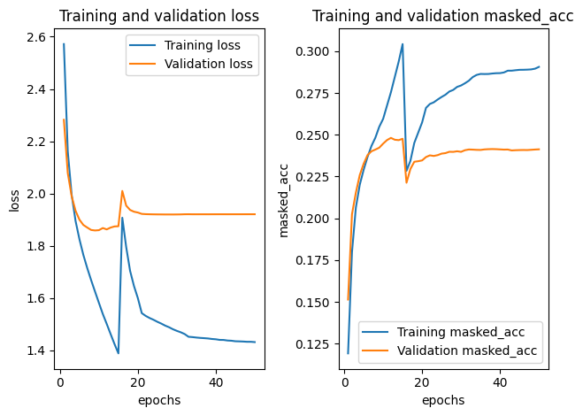

```
best_epoch is 12
122/122 ━━━━━━━━━━━━━━━━━━━━ 141s 1s/step - loss: 2.9375 - masked_acc: 0.1010 - learning_rate: 0.0010
122/122 ━━━━━━━━━━━━━━━━━━━━ 135s 1s/step - loss: 2.2269 - masked_acc: 0.1666 - learning_rate: 0.0010
122/122 ━━━━━━━━━━━━━━━━━━━━ 137s 1s/step - loss: 2.0374 - masked_acc: 0.2024 - learning_rate: 0.0010
122/122 ━━━━━━━━━━━━━━━━━━━━ 138s 1s/step - loss: 1.9235 - masked_acc: 0.2169 - learning_rate: 0.0010
122/122 ━━━━━━━━━━━━━━━━━━━━ 134s 1s/step - loss: 1.8419 - masked_acc: 0.2277 - learning_rate: 0.0010
122/122 ━━━━━━━━━━━━━━━━━━━━ 138s 1s/step - loss: 1.7788 - masked_acc: 0.2354 - learning_rate: 0.0010
122/122 ━━━━━━━━━━━━━━━━━━━━ 136s 1s/step - loss: 1.7240 - masked_acc: 0.2432 - learning_rate: 0.0010
122/122 ━━━━━━━━━━━━━━━━━━━━ 135s 1s/step - loss: 1.6740 - masked_acc: 0.2495 - learning_rate: 0.0010
122/122 ━━━━━━━━━━━━━━━━━━━━ 135s 1s/step - loss: 1.6280 - masked_acc: 0.2544 - learning_rate: 0.0010
122/122 ━━━━━━━━━━━━━━━━━━━━ 137s 1s/step - loss: 1.5811 - masked_acc: 0.2599 - learning_rate: 0.0010
122/122 ━━━━━━━━━━━━━━━━━━━━ 136s 1s/step - loss: 1.5372 - masked_acc: 0.2666 - learning_rate: 0.0010
122/122 ━━━━━━━━━━━━━━━━━━━━ 134s 1s/step - loss: 1.4930 - masked_acc: 0.2753 - learning_rate: 0.0010
Saving to model/summarization_model_2024-09-04_22-55-06.keras
Successfully saved model to model/summarization_model_2024-09-04_22-55-06.keras
{'precision': <tf.Tensor: shape=(), dtype=float32, numpy=0.1585912>, 'recall': <tf.Tensor: shape=(), dtype=float32, numpy=0.08318526>, 'f1_score': <tf.Tensor: shape=(), dtype=float32, numpy=0.10368841>}
{'precision': <tf.Tensor: shape=(), dtype=float32, numpy=0.017895356>, 'recall': <tf.Tensor: shape=(), dtype=float32, numpy=0.007611615>, 'f1_score': <tf.Tensor: shape=(), dtype=float32, numpy=0.010071154>}
{'precision': <tf.Tensor: shape=(), dtype=float32, numpy=0.1470934>, 'recall': <tf.Tensor: shape=(), dtype=float32, numpy=0.078534834>, 'f1_score': <tf.Tensor: shape=(), dtype=float32, numpy=0.097285785>}
```

```python
LEARNING_RATE = 0.001
NUM_EPOCHS = 50
STEPS_PER_EPOCH = None
ENCODER_SEQUENCE_LENGTH = 128 # 128: 75% covered. max is 803.
DECODER_SEQUENCE_LENGTH = 64 # 32: 75% covered. max is 64
MASK_ZERO = False

optimizer = keras.optimizers.AdamW(
    learning_rate=LEARNING_RATE,
)

model, filepath, history = build_model(
    train_ds, validation_ds, test_ds,
    vectorization_layer=vectorization_layer,
    dropout=0.35,
    latent_dim=512,
    encoder_sequence_length=ENCODER_SEQUENCE_LENGTH,
    decoder_sequence_length=DECODER_SEQUENCE_LENGTH,
    vocab_size=VOCABULARY_SIZE,
    batch_size=128,
    embedding_dim=128,
    mask_zero=MASK_ZERO,
    optimizer=optimizer,
    epochs=NUM_EPOCHS,
    steps_per_epoch=STEPS_PER_EPOCH,
    callbacks=[reduce_lr_callbacks],
)
plot(history=history)

optimizer = keras.optimizers.AdamW(
    learning_rate=LEARNING_RATE,
)
best_epoch = max(np.argmin(history.history[f"val_loss"]), np.argmax(history.history[f"val_masked_acc"]))
best_epoch = best_epoch + 1
print("best_epoch is", best_epoch)
model, filepath, history = build_model(
    train_ds.concatenate(validation_ds), None, test_ds,
    vectorization_layer=vectorization_layer,
    dropout=0.35,
    latent_dim=512,
    encoder_sequence_length=ENCODER_SEQUENCE_LENGTH,
    decoder_sequence_length=DECODER_SEQUENCE_LENGTH,
    vocab_size=VOCABULARY_SIZE,
    batch_size=128,
    embedding_dim=128,
    mask_zero=MASK_ZERO,
    optimizer=optimizer,
    epochs=best_epoch,
    steps_per_epoch=STEPS_PER_EPOCH,
    callbacks=[reduce_lr_callbacks],
)

y_true, y_pred = predict_dataset(
    model=model,
    iterable_dataset=tfds.as_numpy(test_ds), # The length of the test dataset is 819.
    decoder_sequence_length=DECODER_SEQUENCE_LENGTH
)
rouge_1_score, rouge_2_score, rouge_l_score = calculate_rouge_score(
    y_true=y_true,
    y_pred=y_pred
)
print(rouge_1_score)
print(rouge_2_score)
print(rouge_l_score)
```

```python
_, _, tds = build_datasets(
    train_ds=train_ds,
    validation_ds=validation_ds,
    test_ds=test_ds,
    vectorization_layer=vectorization_layer,
    batch_size=128,
    encoder_sequence_length=ENCODER_SEQUENCE_LENGTH,
    decoder_sequence_length=DECODER_SEQUENCE_LENGTH,
)
model.evaluate(tds)
```

```
7/7 ━━━━━━━━━━━━━━━━━━━━ 3s 285ms/step - loss: 1.7592 - masked_acc: 0.2510
```

```
[1.7630512714385986, 0.24758540093898773]
```

```python
import time

start = time.time()
y_true, y_pred = predict_dataset(
    model=model,
    iterable_dataset=tfds.as_numpy(test_ds), # The length of the test dataset is 819.
    decoder_sequence_length=DECODER_SEQUENCE_LENGTH,
    use_post_processing=True,
)
print(time.time() - start)
y_true[:5], y_pred[:5]
```

```
466.8963029384613
```

```
(["Hannah needs Betty's number but Amanda doesn't have it. She needs to contact Larry.",
  'Eric and Rob are going to watch a stand-up on youtube.',
  "Lenny can't decide which trousers to buy. Bob advised Lenny on that topic. Lenny goes with Bob's advice to pick the trousers that are of best quality.",
  'Emma will be home soon and she will let Will know.',
  "Jane is in Warsaw. Ollie and Jane has a party. Jane lost her calendar. They will get a lunch this week on Friday. Ollie accidentally called Jane and talked about whisky. Jane cancels lunch. They'll meet for a tea at 6 pm."],
 ['Tom and tom are going to the cinema.',
  'Tom and tom are going to the cinema.',
  'The team is in the hospital. The weather is in the hospital.',
  'Tom and tom are going to the cinema.',
  'The team is in the hospital. The weather is in the hospital.'])
```

## Transformer Encoder-Decoder Model

Initially, the `TransformerEncoderDecoderModel` class is defined as a sub-class of `keras.Model`. The first diagram (Figure 4.3) is a simple architecture of this model, where the model holds 2 encoders and 2 decoders. The second diagram (Figure 4.4), which is made of the same class, represents that the 2 encoders and the 2 decoders have the residual connections.

[figure not shown]

Figure 4.3: Transformer Encoder-Decoder Model Graph

[figure not shown]

Figure 4.4: Transformer Encoder-Decoder Model with Residual Connection Graph

The other advantage of using the subclassing API of TensorFlow is the capability to save the vocabulary data together into a model file easily, aside from the dynamic customization of the model architecture and the training loop. The vocabulary data, which is held in the 2 TextVectorization layers, is saved in the table of the actual words and their internal IDs with trained parameters in this implementation.

````python
@saving.register_keras_serializable()
class TransformerEncoderDecoderModel(keras.Model):
    """
    Transformer model class that contains Transformer Encoder and Decoder inside.
    :param encoder_tokenizer: tf.keras.layers.TextVectorization object
    :param decoder_tokenizer: tf.keras.layers.TextVectorization object
    :num_encoders: the number of encoders
    :num_decoders: the number of decoders
    :num_heads: the number of heads (Attention mechanism)
    :dropout: the dropout rate
    :transformer_intermediate_dim: the number of dimensions in each encoder and decoder
    :normalize_first: Pre-Layer Normalization or Post-Layer Normalization
    :layer_norm_epsilon: the epsilon value in layer normalization components.
    :encoder_vocabulary_size: the number of encoder vocabulary size
    :decoder_vocabulary_size: the number of decoder vocabulary size
    :embedding_dim: the dimension for embedding
    :mask_zero: whether 0 is used the mask value
    :encoder_sequence_length: the length of encoder sequence
    :decoder_sequence_length: the length of decoder sequence
    :use_residual: whether residual connections are used outside of the Transformer encoder and decoder
    """
    def __init__(
        self,
        encoder_tokenizer,
        decoder_tokenizer,
        num_encoders,
        num_decoders,
        num_heads,
        dropout,
        transformer_intermediate_dim,
        normalize_first,
        layer_norm_epsilon,
        encoder_vocabulary_size,
        decoder_vocabulary_size,
        embedding_dim,
        mask_zero,
        encoder_sequence_length,
        decoder_sequence_length,
        use_residual,
        **kwargs):
        super(TransformerEncoderDecoderModel, self).__init__(**kwargs)
        self.mask_zero = mask_zero
        self.layer_norm_epsilon = layer_norm_epsilon
        self.use_residual = use_residual
        self.encoders = []
        self.decoders = []
        if isinstance(layer_norm_epsilon, list):
            encoder_layer_norm_epsilons = layer_norm_epsilon
            decoder_layer_norm_epsilons = layer_norm_epsilon
        else:
            encoder_layer_norm_epsilons = [layer_norm_epsilon for _ in range(num_encoders)]
            decoder_layer_norm_epsilons = [layer_norm_epsilon for _ in range(num_decoders)]

        for i in range(num_encoders):
            self.encoders.append(
                keras_nlp.layers.TransformerEncoder(
                    num_heads=num_heads,
                    dropout=dropout,
                    intermediate_dim=transformer_intermediate_dim,
                    normalize_first=normalize_first,
                    layer_norm_epsilon=encoder_layer_norm_epsilons[i],
                    name=f"encoder_{i}",
                )
            )
        for i in range(num_decoders):
            self.decoders.append(
                keras_nlp.layers.TransformerDecoder(
                    num_heads=num_heads,
                    dropout=dropout,
                    intermediate_dim=transformer_intermediate_dim,
                    normalize_first=normalize_first,
                    layer_norm_epsilon=decoder_layer_norm_epsilons[i],
                    name=f"decoder_{i}",
                )
            )

        self.encoder_tokenizer = encoder_tokenizer
        self.decoder_tokenizer = decoder_tokenizer

        self.encoder_embedding = keras_nlp.layers.TokenAndPositionEmbedding(
            vocabulary_size=encoder_vocabulary_size,
            sequence_length=encoder_sequence_length,
            embedding_dim=embedding_dim,
            mask_zero=mask_zero,
            name="encoder_embed",
        )

        self.decoder_embedding = keras_nlp.layers.TokenAndPositionEmbedding(
            vocabulary_size=decoder_vocabulary_size,
            sequence_length=decoder_sequence_length,
            embedding_dim=embedding_dim,
            mask_zero=mask_zero,
            name="decoder_embed",
        )

        self.dense = keras.layers.Dense(
            decoder_vocabulary_size,
            name="dense",
        )

    def build(self, input_shape):
        """
        This method must set the shapes of tensors into every layer.
        @see https://github.com/keras-team/keras/issues/19535#issuecomment-2060299275
        fcollet has answered and explained how to implement for the following warning.

        ```
        UserWarning: `build()` was called on layer 'transformer_encoder_decoder_model_*',
        however the layer does not have a `build()` method implemented and it looks like it has unbuilt state.
        This will cause the layer to be marked as built, despite not being actually built, which may cause failures down the line.
        Make sure to implement a proper `build()` method
        ```

        The incorrect implementation of this method causes the following problem:
        - When the model is generated from .keras file, the loaded model does not work correctly.
        """
        self.encoder_embedding.build(input_shape[0])
        self.decoder_embedding.build(input_shape[1])
        encoder_output_shape = self.encoder_embedding.compute_output_shape(input_shape[0])
        decoder_output_shape = self.decoder_embedding.compute_output_shape(input_shape[1])

        for encoder in self.encoders:
            encoder.build(inputs_shape=encoder_output_shape)
            encoder_output_shape = encoder.compute_output_shape(
                inputs_shape=encoder_output_shape
            )
        for decoder in self.decoders:
            decoder.build(
                decoder_sequence_shape=decoder_output_shape,
                encoder_sequence_shape=encoder_output_shape,
            )
            decoder_output_shape = decoder.compute_output_shape(
                decoder_sequence_shape=decoder_output_shape,
            )

        self.dense.build(input_shape=decoder_output_shape)
        self.built = True

    def call(self, inputs, training=False):
        """
        This method defines and represents the calculation graph (tensor flow).
        :training: True, when calculating val_loss and val_acc. Otherwise, False.
        """
        encoder_input, decoder_input = (
            inputs[0],
            inputs[1],
        )
        encoded = self.encoder_embedding(encoder_input)
        for encoder in self.encoders:
            if self.use_residual and len(self.encoders) > 1:
                residual = encoded
            encoded = encoder(
                inputs=encoded,
                training=training,
            )
            if self.use_residual and len(self.encoders) > 1:
                encoded = encoded + residual

        decoded = self.decoder_embedding(decoder_input)
        for decoder in self.decoders:
            if self.use_residual and len(self.decoders) > 1:
                residual = decoded
            decoded = decoder(
                decoder_sequence=decoded,
                encoder_sequence=encoded,
                use_causal_mask=True,
                training=training,
            )
            if self.use_residual and len(self.decoders) > 1:
                decoded = decoded + residual

        output = self.dense(decoded)

        try:
            # Drop the keras mask, so it doesn't scale the losses/metrics.
            # b/250038731
            del output._keras_mask
        except AttributeError:
            pass
        return output

    def get_config(self):
        """
        This method is used to save a model into a file.
        """
        config = super(TransformerEncoderDecoderModel, self).get_config().copy()
        config.update({
            "encoder_tokenizer": self.encoder_tokenizer.get_config(),
            "decoder_tokenizer": self.decoder_tokenizer.get_config(),
            "num_encoders": len(self.encoders),
            "num_decoders": len(self.decoders),
            "num_heads": self.encoders[0].num_heads,
            "dropout" : self.encoders[0].dropout,
            "transformer_intermediate_dim": self.encoders[0].intermediate_dim,
            "normalize_first": self.encoders[0].normalize_first,
            "layer_norm_epsilon": self.layer_norm_epsilon,
            "encoder_vocabulary_size": self.encoder_embedding.vocabulary_size,
            "decoder_vocabulary_size": self.decoder_embedding.vocabulary_size,
            "embedding_dim": self.encoder_embedding.embedding_dim,
            "mask_zero": self.mask_zero,
            "encoder_sequence_length": self.encoder_embedding.sequence_length,
            "decoder_sequence_length": self.decoder_embedding.sequence_length,
            "use_residual": self.use_residual,
        })
        return config
    @classmethod
    def from_config(cls, config):
        """
        This method is used to build a model from a saved file.
        """
        encoder_tokenizer_config = config.pop("encoder_tokenizer")
        decoder_tokenizer_config = config.pop("decoder_tokenizer")
        encoder_tokenizer = keras.layers.TextVectorization.from_config(encoder_tokenizer_config)
        decoder_tokenizer = keras.layers.TextVectorization.from_config(decoder_tokenizer_config)
        return cls(
            encoder_tokenizer=encoder_tokenizer,
            decoder_tokenizer=decoder_tokenizer,
            **config
        )
````

### Prediction

Firstly, the text that is summarized and the start OOV token "[start]" are given into the encoder input and the decoder input, respectively. Then, the first word that follows "[start]" is derived from the decoder output. Next, the outputted word is combined with the previous input sequence, and it is used as the next input sequence of the decoder input. At this time, the encoder input is not changed. This process is repeatedly executed until the decoder output contains the end OOV token "[end]" or reaches the maximum length. Finally, the summarized text is completed.

Unlike the classification task, it computationally takes O(n) in proportion to the length of the summarized text. That might be one of the disadvantages if the task summarizes much longer text.

```python
import nltk
nltk.download('punkt')
nltk.download('averaged_perceptron_tagger')

def post_process(text):
    text = text.replace("[start] ", "")
    text = text.replace(" [end]", "")
    sentences = nltk.sent_tokenize(text)
    ss = []
    for sentence in sentences:
        sentence = sentence.capitalize()
        tokens = nltk.tokenize.word_tokenize(text=sentence)
        tagged_tokens = nltk.tag.pos_tag(tokens=tokens)
        result = []
        for i, (token, tag) in enumerate(tagged_tokens):
            if i == 0:  # The first word of the sentence
                result.append(token.capitalize())
            elif tag.startswith('NNP'):  # proper noun
                result.append(token.capitalize())
            else:
                result.append(token.lower())
        s = " ".join(result)
        ss.append(s)
    text = " ".join(ss)
    text = text.replace(" ,", ",")
    text = text.replace(" .", ".")
    # Revert OOV.
    # text = '[start] ' + text + ' [end]'
    return text

def decode_sequence(
        input_sentence,
        model,
        max_sequence_length,
        lookup_table,
        use_post_processing=False):
    """
    Generate summarized text from the input sentence.
    :input_sentence: the original text that is summarized
    :model: the TransformerEncoderDecoderModel class model
    :max_sequence_length: the maximum length of the summarized text
    :lookup_table: the table holds token IDs and their actual words
    """
    encoder_tokenizer = model.encoder_tokenizer
    decoder_tokenizer = model.decoder_tokenizer
    tokenized_input = encoder_tokenizer([input_sentence])

    start_token = decoder_tokenizer("[start]")[0].numpy()
    end_token = decoder_tokenizer("[end]")[0].numpy()

    decoded_sentence = [start_token]
    for i in range(max_sequence_length):
        decoder_inputs = tf.convert_to_tensor(
            [decoded_sentence],
            dtype="int64",
        )
        decoder_inputs = tf.concat(
            [
                decoder_inputs,
                tf.zeros(
                    [1, max_sequence_length - i - 1],
                    dtype="int64",
                ),
            ],
            axis=1,
        )
        input = (
            tokenized_input,
            decoder_inputs,
        )
        predictions = model(input)
        predicted_token = np.argmax(predictions[0, i, :])
        decoded_sentence.append(predicted_token)
        if predicted_token == end_token:
            break

    detokenized_output = []
    for token in decoded_sentence:
        detokenized_output.append(lookup_table[token])
    text = " ".join(detokenized_output)
    if use_post_processing:
        text = post_process(text=text)
    return text


def predict_main(
        filepath,
        examples,
        decoder_sequence_length,
        use_post_processing=False):
    """
    Generate summarized text with the model file.
    :filepath: the file path specifies the model
    :examples: the list of text that is summarized.
    :decoder_sequence_length: the maximum length of the summarized text.
    """
    loaded_model = keras.models.load_model(
        filepath,
        # Just in case, TransformerEncoderDecoderModel is specified.
        # However, it does not seem necessary.
        custom_objects={
            "TransformerEncoderDecoderModel": TransformerEncoderDecoderModel,
            "Seq2SeqModel": Seq2SeqModel,
        }
    )

    decoder_tokenizer = loaded_model.decoder_tokenizer
    vocab = decoder_tokenizer.get_vocabulary()
    index_lookup_table = dict(zip(range(len(vocab)), vocab))

    summarized = []
    for example in examples:
        summarized.append(
            decode_sequence(
                example,
                loaded_model,
                decoder_sequence_length,
                index_lookup_table,
                use_post_processing=use_post_processing,
            )
        )

    for i in range(len(examples)):
        print("ORIGINAL SENTENCE: ", examples[i])
        print("SUMMARIZED RESULT: ", summarized[i])

def predict_model(
        model,
        examples,
        decoder_sequence_length,
        use_post_processing=False):
    """
    Generate summarized text with the model.
    :model: the file path specifies the model
    :examples: the list of text that is summarized.
    :decoder_sequence_length: the maximum length of the summarized text.
    """
    decoder_tokenizer = model.decoder_tokenizer
    vocab = decoder_tokenizer.get_vocabulary()
    index_lookup_table = dict(zip(range(len(vocab)), vocab))

    summarized = []
    for example in examples:
        summarized.append(
            decode_sequence(
                example,
                model,
                decoder_sequence_length,
                index_lookup_table,
                use_post_processing=use_post_processing,
            )
        )

    for i in range(len(examples)):
        print("ORIGINAL SENTENCE: ", examples[i])
        print("SUMMARIZED RESULT: ", summarized[i])

def predict_dataset(
        model,
        iterable_dataset,
        decoder_sequence_length,
        use_post_processing=False):
    """
    Generate summarized text with the model.
    :model: the file path specifies the model
    :iterable_dataset: the dataset, which is mainly test set, used to generate summarized text.
    :decoder_sequence_length: the maximum length of the summarized text.
    """
    decoder_tokenizer = model.decoder_tokenizer
    vocab = decoder_tokenizer.get_vocabulary()
    index_lookup_table = dict(zip(range(len(vocab)), vocab))

    y_trues = []
    y_preds = []
    for entry in iterable_dataset:
        text = entry["dialogue"]
        result = decode_sequence(
            text,
            model,
            decoder_sequence_length,
            index_lookup_table,
            use_post_processing=use_post_processing,
        )
        y_true = entry["summary"]
        y_true = y_true.decode('utf-8')
        y_pred = result.replace('[start]', '').replace('[end]', '').strip()
        # print(y_true, '\n\t' , y_pred)
        y_trues.append(y_true)
        y_preds.append(y_pred)
    return y_trues, y_preds

def calculate_rouge_score(y_true, y_pred):
    """
    # RougeN metric
    # @see https://keras.io/api/keras_nlp/metrics/rouge_n/
    """
    rouge_n = keras_nlp.metrics.RougeN(order=2)
    rouge_2_score = rouge_n(y_true, y_pred)
    rouge_n = keras_nlp.metrics.RougeN(order=1)
    rouge_1_score = rouge_n(y_true, y_pred)
    rouge_l = keras_nlp.metrics.RougeL()
    rouge_l_score = rouge_l(y_true, y_pred)
    return rouge_1_score, rouge_2_score, rouge_l_score
```

### Training

The `build_model` method is defined with various arguments so that hyperparameters can be injected from outside. Hereby, the same method can be used for various hyperparameter tunings.

```python
def run_training(
        model,
        train_ds,
        validation_ds,
        optimizer,
        epochs,
        steps_per_epoch,
        now,
        verbose,
        callbacks=[]):
    """
    Run training.
    :train_ds: training set
    :validation_ds: validation set
    :optimizer: optimizer.Optimizer
    :epochs: the number of epochs
    :steps_per_epoch: the number of weight updates in a epoch
    :now: timestamp
    """
    metrics = [
        masked_acc,
        #keras.metrics.SparseCategoricalAccuracy(),
        #keras_nlp.metrics.RougeN(), #  This cannot be used here
    ]
    model.compile(
        optimizer=optimizer,
        metrics=metrics,
        loss=masked_loss,
        weighted_metrics=[],
    )
    callbacks.append(get_tensorboard_callback(now=now))
    history = model.fit(
        train_ds,
        epochs=epochs,
        validation_data=validation_ds,
        steps_per_epoch=steps_per_epoch,
        callbacks=callbacks,
        verbose=verbose,
    )
    return history
```

```python
class RougeEvaluator(keras.callbacks.Callback):
    """
    Callback to calculate ROUGE scores for every epoch
    """
    def __init__(
            self,
            dataset,
            max_length):
        """
        :dataset: dataset object that is used for ROUGE evaluation
        :max_length: the max length of the summarized text
        """
        self.dataset = dataset
        self.max_length = max_length

    def on_epoch_end(self, epoch, logs=None):
        y_true, y_pred = predict_dataset(
            model=self.model,
            iterable_dataset=tfds.as_numpy(self.dataset),
            decoder_sequence_length=self.max_length
        )
        rouge_1_score, rouge_2_score, rouge_l_score = calculate_rouge_score(
            y_true=y_true,
            y_pred=y_pred
        )
        print(rouge_1_score)
        print(rouge_2_score)
        print(rouge_l_score)

def build_model(
        train_ds, validation_ds, test_ds,
        vectorization_layer,
        num_encoders,
        num_decoders,
        num_heads,
        dropout,
        transformer_intermediate_dim,
        normalize_first,
        layer_norm_epsilon,
        encoder_sequence_length,
        decoder_sequence_length,
        use_residual,
        vocab_size,
        batch_size,
        embedding_dim,
        mask_zero,
        optimizer,
        epochs,
        steps_per_epoch,
        verbose=1,
        callbacks=[]):
    """
    Build the model with specified parameters.
    :return: model: trained model
    :return: filepath: model file path if it is saved
    :return: history: history object to plot
    """
    now = datetime.datetime.now()
    if DEBUGGER_V2:
        tf.debugging.experimental.enable_dump_debug_info(
            get_log_dir(now=now),
            tensor_debug_mode="FULL_HEALTH",
            circular_buffer_size=-1
        )
    # before validation_ds is transformed
    # if verbose > 0 and validation_ds is not None:
    #     callbacks.append(RougeEvaluator(
    #         dataset=validation_ds,
    #         max_length=decoder_sequence_length,
    #     ))
    input_vectorization_layer, target_vectorization_layer = prepare_tokenizer(
        vectorization_layer=vectorization_layer,
        encoder_sequence_length=encoder_sequence_length,
        decoder_sequence_length=decoder_sequence_length,
        max_tokens=vocab_size,
    )
    train_ds, validation_ds, test_ds = build_datasets(
        train_ds=train_ds,
        validation_ds=validation_ds,
        test_ds=test_ds,
        vectorization_layer=vectorization_layer,
        batch_size=batch_size,
        encoder_sequence_length=encoder_sequence_length,
        decoder_sequence_length=decoder_sequence_length,
    )

    input_vocab_size = input_vectorization_layer.vocabulary_size()
    target_vocab_size = target_vectorization_layer.vocabulary_size()
    model = TransformerEncoderDecoderModel(
        encoder_tokenizer=input_vectorization_layer,
        decoder_tokenizer=target_vectorization_layer,
        num_encoders=num_encoders,
        num_decoders=num_decoders,
        num_heads=num_heads,
        dropout=dropout,
        transformer_intermediate_dim=transformer_intermediate_dim,
        normalize_first=normalize_first,
        layer_norm_epsilon=layer_norm_epsilon,
        encoder_vocabulary_size=input_vocab_size,
        decoder_vocabulary_size=target_vocab_size,
        embedding_dim=embedding_dim,
        mask_zero=mask_zero,
        encoder_sequence_length=encoder_sequence_length,
        decoder_sequence_length=decoder_sequence_length,
        use_residual=use_residual,
    )
    # This should be called seemingly.
    model.build(
        input_shape=(
            (None, encoder_sequence_length),
            (None, decoder_sequence_length)
        )
    )

    history = run_training(
        model,
        train_ds=train_ds,
        validation_ds=validation_ds,
        optimizer=optimizer,
        epochs=epochs,
        steps_per_epoch=steps_per_epoch,
        now=now,
        verbose=verbose,
        callbacks=callbacks,
    )

    timestamp = now.strftime('%Y-%m-%d_%H-%M-%S')
    if is_running_on_apple_silicon() or is_running_on_intel_mac():
        filepath = f'model/summarization_model_{timestamp}.keras'
    else:
        filepath = f'summarization_model_{timestamp}.keras'
    print(f"Saving to {filepath}")
    model.save(filepath=filepath)

    print(f"Successfully saved model to {filepath}")
    return model, filepath, history
```

### Build

The best model is built with the hyperparameter set, which is derived by the experiments.

```python
ADAPT_BATCH_SIZE = 256

train_ds, validation_ds, test_ds = prepare_datasets()
vectorization_layer = keras.layers.TextVectorization(
    standardize=custom_standardization,
    # max_tokens=VOCABULARY_SIZE,
    output_mode='int',
    ragged=True,
)
vectorization_layer.adapt(
    train_ds.batch(ADAPT_BATCH_SIZE).map(
        lambda row: '[start] ' + row['summary'] + ' ' + row['dialogue'] + ' [end]',
        num_parallel_calls=tf.data.AUTOTUNE,
    ),
    batch_size=ADAPT_BATCH_SIZE,
)
# Use the maximum size of the dataset. 31907
VOCABULARY_SIZE = len(vectorization_layer.get_vocabulary())
```

[output not shown]

```
2024-08-16 01:58:53.066230: I tensorflow/core/grappler/optimizers/custom_graph_optimizer_registry.cc:117] Plugin optimizer for device_type GPU is enabled.
```

```
116/116 ━━━━━━━━━━━━━━━━━━━━ 74s 490ms/step - loss: 2.5703 - masked_acc: 0.0687 - val_loss: 1.8928 - val_masked_acc: 0.1604 - learning_rate: 0.0010
116/116 ━━━━━━━━━━━━━━━━━━━━ 53s 448ms/step - loss: 1.8166 - masked_acc: 0.1712 - val_loss: 1.8283 - val_masked_acc: 0.1721 - learning_rate: 0.0010
116/116 ━━━━━━━━━━━━━━━━━━━━ 51s 440ms/step - loss: 1.6689 - masked_acc: 0.1983 - val_loss: 1.7943 - val_masked_acc: 0.1821 - learning_rate: 0.0010
116/116 ━━━━━━━━━━━━━━━━━━━━ 52s 449ms/step - loss: 1.5317 - masked_acc: 0.2305 - val_loss: 1.7490 - val_masked_acc: 0.2128 - learning_rate: 0.0010
116/116 ━━━━━━━━━━━━━━━━━━━━ 51s 443ms/step - loss: 1.3796 - masked_acc: 0.2739 - val_loss: 1.7347 - val_masked_acc: 0.2292 - learning_rate: 0.0010
116/116 ━━━━━━━━━━━━━━━━━━━━ 52s 445ms/step - loss: 1.2345 - masked_acc: 0.3130 - val_loss: 1.7604 - val_masked_acc: 0.2320 - learning_rate: 0.0010
116/116 ━━━━━━━━━━━━━━━━━━━━ 52s 443ms/step - loss: 1.1078 - masked_acc: 0.3520 - val_loss: 1.7971 - val_masked_acc: 0.2368 - learning_rate: 0.0010
116/116 ━━━━━━━━━━━━━━━━━━━━ 53s 452ms/step - loss: 0.9896 - masked_acc: 0.3929 - val_loss: 1.8437 - val_masked_acc: 0.2364 - learning_rate: 0.0010
116/116 ━━━━━━━━━━━━━━━━━━━━ 53s 452ms/step - loss: 0.8867 - masked_acc: 0.4370 - val_loss: 1.9127 - val_masked_acc: 0.2351 - learning_rate: 0.0010
116/116 ━━━━━━━━━━━━━━━━━━━━ 50s 430ms/step - loss: 0.8017 - masked_acc: 0.4746 - val_loss: 1.9689 - val_masked_acc: 0.2253 - learning_rate: 0.0010
116/116 ━━━━━━━━━━━━━━━━━━━━ 49s 424ms/step - loss: 0.7321 - masked_acc: 0.5098 - val_loss: 2.0139 - val_masked_acc: 0.2300 - learning_rate: 0.0010
116/116 ━━━━━━━━━━━━━━━━━━━━ 51s 438ms/step - loss: 0.6693 - masked_acc: 0.5411 - val_loss: 2.0612 - val_masked_acc: 0.2338 - learning_rate: 0.0010
116/116 ━━━━━━━━━━━━━━━━━━━━ 52s 448ms/step - loss: 0.6114 - masked_acc: 0.5719 - val_loss: 2.1377 - val_masked_acc: 0.2299 - learning_rate: 0.0010
116/116 ━━━━━━━━━━━━━━━━━━━━ 52s 450ms/step - loss: 0.5671 - masked_acc: 0.5961 - val_loss: 2.2052 - val_masked_acc: 0.2261 - learning_rate: 0.0010
116/116 ━━━━━━━━━━━━━━━━━━━━ 50s 431ms/step - loss: 0.5199 - masked_acc: 0.6244 - val_loss: 2.2616 - val_masked_acc: 0.2294 - learning_rate: 0.0010
116/116 ━━━━━━━━━━━━━━━━━━━━ 51s 442ms/step - loss: 0.4845 - masked_acc: 0.6422 - val_loss: 2.3103 - val_masked_acc: 0.2276 - learning_rate: 0.0010
116/116 ━━━━━━━━━━━━━━━━━━━━ 50s 433ms/step - loss: 0.4525 - masked_acc: 0.6616 - val_loss: 2.3600 - val_masked_acc: 0.2263 - learning_rate: 0.0010
116/116 ━━━━━━━━━━━━━━━━━━━━ 50s 427ms/step - loss: 0.4248 - masked_acc: 0.6793 - val_loss: 2.4122 - val_masked_acc: 0.2176 - learning_rate: 0.0010
116/116 ━━━━━━━━━━━━━━━━━━━━ 50s 427ms/step - loss: 0.3991 - masked_acc: 0.6958 - val_loss: 2.4476 - val_masked_acc: 0.2180 - learning_rate: 0.0010
116/116 ━━━━━━━━━━━━━━━━━━━━ 50s 434ms/step - loss: 0.3755 - masked_acc: 0.7118 - val_loss: 2.4973 - val_masked_acc: 0.2199 - learning_rate: 0.0010
116/116 ━━━━━━━━━━━━━━━━━━━━ 50s 434ms/step - loss: 0.3574 - masked_acc: 0.7227 - val_loss: 2.5602 - val_masked_acc: 0.2155 - learning_rate: 0.0010
116/116 ━━━━━━━━━━━━━━━━━━━━ 50s 431ms/step - loss: 0.3412 - masked_acc: 0.7323 - val_loss: 2.6092 - val_masked_acc: 0.2182 - learning_rate: 0.0010
116/116 ━━━━━━━━━━━━━━━━━━━━ 51s 436ms/step - loss: 0.3263 - masked_acc: 0.7427 - val_loss: 2.6564 - val_masked_acc: 0.2185 - learning_rate: 0.0010
116/116 ━━━━━━━━━━━━━━━━━━━━ 51s 435ms/step - loss: 0.3083 - masked_acc: 0.7545 - val_loss: 2.6988 - val_masked_acc: 0.2174 - learning_rate: 0.0010
116/116 ━━━━━━━━━━━━━━━━━━━━ 51s 435ms/step - loss: 0.2946 - masked_acc: 0.7643 - val_loss: 2.7433 - val_masked_acc: 0.2065 - learning_rate: 0.0010
116/116 ━━━━━━━━━━━━━━━━━━━━ 51s 435ms/step - loss: 0.2848 - masked_acc: 0.7710 - val_loss: 2.7614 - val_masked_acc: 0.2076 - learning_rate: 0.0010
116/116 ━━━━━━━━━━━━━━━━━━━━ 50s 434ms/step - loss: 0.2727 - masked_acc: 0.7782 - val_loss: 2.7925 - val_masked_acc: 0.2115 - learning_rate: 0.0010
116/116 ━━━━━━━━━━━━━━━━━━━━ 50s 433ms/step - loss: 0.2621 - masked_acc: 0.7866 - val_loss: 2.8295 - val_masked_acc: 0.2110 - learning_rate: 0.0010
116/116 ━━━━━━━━━━━━━━━━━━━━ 50s 430ms/step - loss: 0.2498 - masked_acc: 0.7960 - val_loss: 2.8748 - val_masked_acc: 0.2087 - learning_rate: 0.0010
116/116 ━━━━━━━━━━━━━━━━━━━━ 50s 427ms/step - loss: 0.2424 - masked_acc: 0.8002 - val_loss: 2.9182 - val_masked_acc: 0.2105 - learning_rate: 0.0010
116/116 ━━━━━━━━━━━━━━━━━━━━ 50s 426ms/step - loss: 0.2345 - masked_acc: 0.8056 - val_loss: 2.9463 - val_masked_acc: 0.2097 - learning_rate: 0.0010
116/116 ━━━━━━━━━━━━━━━━━━━━ 50s 426ms/step - loss: 0.2254 - masked_acc: 0.8136 - val_loss: 2.9823 - val_masked_acc: 0.2124 - learning_rate: 0.0010
116/116 ━━━━━━━━━━━━━━━━━━━━ 50s 428ms/step - loss: 0.2187 - masked_acc: 0.8181 - val_loss: 3.0087 - val_masked_acc: 0.2142 - learning_rate: 0.0010
116/116 ━━━━━━━━━━━━━━━━━━━━ 50s 427ms/step - loss: 0.2117 - masked_acc: 0.8230 - val_loss: 3.0547 - val_masked_acc: 0.2127 - learning_rate: 0.0010
116/116 ━━━━━━━━━━━━━━━━━━━━ 49s 424ms/step - loss: 0.2049 - masked_acc: 0.8280 - val_loss: 3.0827 - val_masked_acc: 0.2126 - learning_rate: 0.0010
116/116 ━━━━━━━━━━━━━━━━━━━━ 50s 429ms/step - loss: 0.2007 - masked_acc: 0.8324 - val_loss: 3.1039 - val_masked_acc: 0.2103 - learning_rate: 0.0010
116/116 ━━━━━━━━━━━━━━━━━━━━ 50s 427ms/step - loss: 0.1945 - masked_acc: 0.8359 - val_loss: 3.1441 - val_masked_acc: 0.2032 - learning_rate: 0.0010
116/116 ━━━━━━━━━━━━━━━━━━━━ 0s 405ms/step - loss: 0.1915 - masked_acc: 0.8371
```

[output cut: 20 more lines]

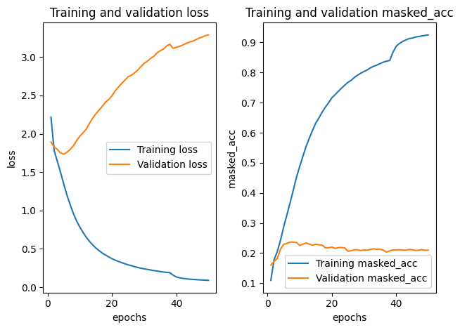

```
best_epoch is 7
122/122 ━━━━━━━━━━━━━━━━━━━━ 78s 475ms/step - loss: 2.5559 - masked_acc: 0.0715 - learning_rate: 0.0010
122/122 ━━━━━━━━━━━━━━━━━━━━ 54s 422ms/step - loss: 1.8059 - masked_acc: 0.1733 - learning_rate: 0.0010
122/122 ━━━━━━━━━━━━━━━━━━━━ 52s 424ms/step - loss: 1.6572 - masked_acc: 0.2007 - learning_rate: 0.0010
122/122 ━━━━━━━━━━━━━━━━━━━━ 51s 418ms/step - loss: 1.5127 - masked_acc: 0.2370 - learning_rate: 0.0010
122/122 ━━━━━━━━━━━━━━━━━━━━ 53s 419ms/step - loss: 1.3551 - masked_acc: 0.2819 - learning_rate: 0.0010
122/122 ━━━━━━━━━━━━━━━━━━━━ 51s 416ms/step - loss: 1.2060 - masked_acc: 0.3225 - learning_rate: 0.0010
122/122 ━━━━━━━━━━━━━━━━━━━━ 53s 425ms/step - loss: 1.0754 - masked_acc: 0.3637 - learning_rate: 0.0010
Saving to model/summarization_model_2024-08-16_02-41-07.keras
Successfully saved model to model/summarization_model_2024-08-16_02-41-07.keras
```

```
2024-08-16 02:58:03.036484: I tensorflow/core/framework/local_rendezvous.cc:404] Local rendezvous is aborting with status: OUT_OF_RANGE: End of sequence
```

```
{'precision': <tf.Tensor: shape=(), dtype=float32, numpy=0.29449987>, 'recall': <tf.Tensor: shape=(), dtype=float32, numpy=0.27281088>, 'f1_score': <tf.Tensor: shape=(), dtype=float32, numpy=0.2631281>}
{'precision': <tf.Tensor: shape=(), dtype=float32, numpy=0.0775297>, 'recall': <tf.Tensor: shape=(), dtype=float32, numpy=0.06793913>, 'f1_score': <tf.Tensor: shape=(), dtype=float32, numpy=0.0666055>}
{'precision': <tf.Tensor: shape=(), dtype=float32, numpy=0.2401143>, 'recall': <tf.Tensor: shape=(), dtype=float32, numpy=0.2251837>, 'f1_score': <tf.Tensor: shape=(), dtype=float32, numpy=0.21557395>}
```

```python
LEARNING_RATE = 0.001
NUM_EPOCHS = 50
STEPS_PER_EPOCH = None
ENCODER_SEQUENCE_LENGTH = 128 # 128: 75% covered. max is 803.
DECODER_SEQUENCE_LENGTH = 64 # 32: 75% covered. max is 64
MASK_ZERO = False

optimizer = keras.optimizers.AdamW(
    learning_rate=LEARNING_RATE,
)

model, filepath, history = build_model(
    train_ds, validation_ds, test_ds,
    vectorization_layer=vectorization_layer,
    num_encoders=2,
    num_decoders=2,
    num_heads=6,
    dropout=0.35,
    transformer_intermediate_dim=512,
    normalize_first=False,
    layer_norm_epsilon=1e-5,
    encoder_sequence_length=ENCODER_SEQUENCE_LENGTH,
    decoder_sequence_length=DECODER_SEQUENCE_LENGTH,
    use_residual=True,
    vocab_size=VOCABULARY_SIZE,
    batch_size=128,
    embedding_dim=128,
    mask_zero=MASK_ZERO,
    optimizer=optimizer,
    epochs=NUM_EPOCHS,
    steps_per_epoch=STEPS_PER_EPOCH,
    callbacks=[reduce_lr_callbacks],
)
plot(history=history)

optimizer = keras.optimizers.AdamW(
    learning_rate=LEARNING_RATE,
)
best_epoch = max(np.argmin(history.history[f"val_loss"]), np.argmax(history.history[f"val_masked_acc"]))
best_epoch = best_epoch + 1
print("best_epoch is", best_epoch)
model, filepath, history = build_model(
    train_ds.concatenate(validation_ds), None, test_ds,
    vectorization_layer=vectorization_layer,
    num_encoders=2,
    num_decoders=2,
    num_heads=6,
    dropout=0.35,
    transformer_intermediate_dim=512,
    normalize_first=False,
    layer_norm_epsilon=1e-5,
    encoder_sequence_length=ENCODER_SEQUENCE_LENGTH,
    decoder_sequence_length=DECODER_SEQUENCE_LENGTH,
    use_residual=True,
    vocab_size=VOCABULARY_SIZE,
    batch_size=128,
    embedding_dim=128,
    mask_zero=MASK_ZERO,
    optimizer=optimizer,
    epochs=best_epoch,
    steps_per_epoch=STEPS_PER_EPOCH,
    callbacks=[reduce_lr_callbacks],
)

y_true, y_pred = predict_dataset(
    model=model,
    iterable_dataset=tfds.as_numpy(test_ds), # The length of the test dataset is 819.
    decoder_sequence_length=DECODER_SEQUENCE_LENGTH,
    use_post_processing=True,
)
rouge_1_score, rouge_2_score, rouge_l_score = calculate_rouge_score(
    y_true=y_true,
    y_pred=y_pred,
)
print(rouge_1_score)
print(rouge_2_score)
print(rouge_l_score)
```

```python
_, _, tds = build_datasets(
    train_ds=train_ds,
    validation_ds=validation_ds,
    test_ds=test_ds,
    vectorization_layer=vectorization_layer,
    batch_size=128,
    encoder_sequence_length=ENCODER_SEQUENCE_LENGTH,
    decoder_sequence_length=DECODER_SEQUENCE_LENGTH,
)
model.evaluate(tds)
```

```
7/7 ━━━━━━━━━━━━━━━━━━━━ 1s 48ms/step - loss: 1.7724 - masked_acc: 0.2751
```

```
[1.7775108814239502, 0.2743791937828064]
```

```python
start = time.time()
y_true, y_pred = predict_dataset(
    model=model,
    iterable_dataset=tfds.as_numpy(test_ds), # The length of the test dataset is 819.
    decoder_sequence_length=DECODER_SEQUENCE_LENGTH,
    use_post_processing=True,
)
print(time.time() - start)
y_true[:5], y_pred[:5]
```

```
2458.630399942398
```

```
2024-08-21 09:54:15.527150: W tensorflow/core/framework/local_rendezvous.cc:404] Local rendezvous is aborting with status: OUT_OF_RANGE: End of sequence
```

```
(["Hannah needs Betty's number but Amanda doesn't have it. She needs to contact Larry.",
  'Eric and Rob are going to watch a stand-up on youtube.',
  "Lenny can't decide which trousers to buy. Bob advised Lenny on that topic. Lenny goes with Bob's advice to pick the trousers that are of best quality.",
  'Emma will be home soon and she will let Will know.',
  "Jane is in Warsaw. Ollie and Jane has a party. Jane lost her calendar. They will get a lunch this week on Friday. Ollie accidentally called Jane and talked about whisky. Jane cancels lunch. They'll meet for a tea at 6 pm."],
 ["Amanda is looking for a car. Amanda forgot her messages, amanda and amanda did n't get him. Hannah and amanda will text amanda.",
  "Eric shares a problem with eric shares a bad sprain trying to look for a snowstorm. Rob does n't like his cardiologist when he will look.",
  'Lenny needs help tom and her photos from the photos of white shirts, tom and bob will buy the photos of the photos of the old ones.',
  'Will pick emma up tonight at home tonight. Emma will pick her up. Emma will be home at home tonight.',
  'Jane is going to warsaw and will be back in warsaw. Jane will call her. Jane will call her. Jane will call her.'])
```

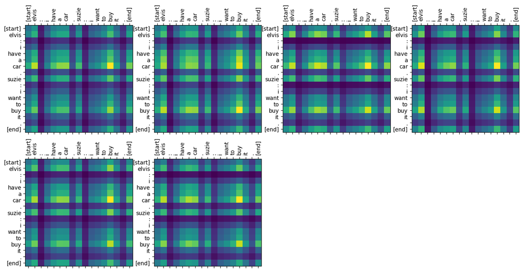

```python
visualize_attention_scores(
    encoder_tokenizer=model.encoder_tokenizer,
    encoder_embedding=model.encoder_embedding,
    attention_layer=model.encoders[0]._self_attention_layer,
    sentence="[start] Elvis: I have a car. Suzie: I want to buy it. [end]",
)
```

## Transformer Decoder-Only Model

To exhibit the superiority of the Transformer encoder-decoder model on text summarization tasks, another architecture, which is the Transformer decoder-only model, is defined as follows (Figure 4.5). This model that is implemented in the `TransformerDecoderModel` class is a simpler architecture where the encoder mechanisms are just removed. Specifically, this model has an embedding layer, 2 Transformer decoder layers, and a dense layer.

[figure not shown]

Figure 4.5: Transformer Decoder-Only Model Graph

```python
@saving.register_keras_serializable()
class TransformerDecoderModel(keras.Model):
    """
    Transformer model class that contains Transformer Decoder inside.
    :param decoder_tokenizer: tf.keras.layers.TextVectorization object
    :num_decoders: the number of decoders
    :num_heads: the number of heads (Attention mechanism)
    :dropout: the dropout rate
    :transformer_intermediate_dim: the number of dimensions in each decoder
    :normalize_first: Pre-Layer Normalization or Post-Layer Normalization
    :layer_norm_epsilon: the epsilon value in layer normalization components.
    :decoder_vocabulary_size: the number of decoder vocabulary size
    :embedding_dim: the dimension for embedding
    :mask_zero: whether 0 is used the mask value
    :decoder_sequence_length: the length of decoder sequence
    :use_residual: whether residual connections are used outside of the Transformer decoder
    """
    def __init__(
        self,
        decoder_tokenizer,
        num_decoders,
        num_heads,
        dropout,
        transformer_intermediate_dim,
        normalize_first,
        layer_norm_epsilon,
        decoder_vocabulary_size,
        embedding_dim,
        mask_zero,
        decoder_sequence_length,
        use_residual,
        **kwargs):
        super(TransformerDecoderModel, self).__init__(**kwargs)
        self.mask_zero = mask_zero
        self.layer_norm_epsilon = layer_norm_epsilon
        self.use_residual = use_residual
        self.decoders = []
        if isinstance(layer_norm_epsilon, list):
            decoder_layer_norm_epsilons = layer_norm_epsilon
        else:
            decoder_layer_norm_epsilons = [layer_norm_epsilon for _ in range(num_decoders)]

        for i in range(num_decoders):
            self.decoders.append(
                keras_nlp.layers.TransformerDecoder(
                    num_heads=num_heads,
                    dropout=dropout,
                    intermediate_dim=transformer_intermediate_dim,
                    normalize_first=normalize_first,
                    layer_norm_epsilon=decoder_layer_norm_epsilons[i],
                    name=f"decoder_{i}",
                )
            )

        self.decoder_tokenizer = decoder_tokenizer

        self.decoder_embedding = keras_nlp.layers.TokenAndPositionEmbedding(
            vocabulary_size=decoder_vocabulary_size,
            sequence_length=decoder_sequence_length,
            embedding_dim=embedding_dim,
            mask_zero=mask_zero,
            name="decoder_embed",
        )

        self.dense = keras.layers.Dense(
            decoder_vocabulary_size,
            name="dense",
        )

    def call(self, inputs, training=False):
        """
        This method defines and represents the calculation graph (tensor flow).
        :training: True, when calculating val_loss and val_acc. Otherwise, False.
        """
        decoder_input = inputs[0]
        decoded = self.decoder_embedding(decoder_input)
        for decoder in self.decoders:
            if self.use_residual and len(self.decoders) > 1:
                residual = decoded
            decoded = decoder(
                decoder_sequence=decoded,
                #encoder_sequence=encoded,
                use_causal_mask=True,
                training=training,
            )
            if self.use_residual and len(self.decoders) > 1:
                decoded = decoded + residual

        output = self.dense(decoded)
        try:
            # Drop the keras mask, so it doesn't scale the losses/metrics.
            # b/250038731
            del output._keras_mask
        except AttributeError:
            pass
        return output

    def get_config(self):
        """
        This method is used to save a model into a file.
        """
        config = super(TransformerDecoderModel, self).get_config().copy()
        config.update({
            "decoder_tokenizer": self.decoder_tokenizer.get_config(),
            "num_decoders": len(self.decoders),
            "num_heads": self.decoders[0].num_heads,
            "dropout" : self.decoders[0].dropout,
            "transformer_intermediate_dim": self.decoders[0].intermediate_dim,
            "normalize_first": self.decoders[0].normalize_first,
            "layer_norm_epsilon": self.layer_norm_epsilon,
            "decoder_vocabulary_size": self.decoder_embedding.vocabulary_size,
            "embedding_dim": self.decoder_embedding.embedding_dim,
            "mask_zero": self.mask_zero,
            "decoder_sequence_length": self.decoder_embedding.sequence_length,
            "use_residual": self.use_residual,
        })
        return config
    @classmethod
    def from_config(cls, config):
        """
        This method is used to build a model from a saved file.
        """
        decoder_tokenizer_config = config.pop("decoder_tokenizer")
        decoder_tokenizer = keras.layers.TextVectorization.from_config(decoder_tokenizer_config)
        return cls(
            decoder_tokenizer=decoder_tokenizer,
            **config
        )
```

```
116/116 ━━━━━━━━━━━━━━━━━━━━ 70s 543ms/step - loss: 7.6512 - masked_acc: 0.0826 - val_loss: 6.4993 - val_masked_acc: 0.1049 - learning_rate: 0.0010
116/116 ━━━━━━━━━━━━━━━━━━━━ 65s 551ms/step - loss: 6.3878 - masked_acc: 0.1030 - val_loss: 6.4758 - val_masked_acc: 0.1048 - learning_rate: 0.0010
116/116 ━━━━━━━━━━━━━━━━━━━━ 63s 545ms/step - loss: 6.2120 - masked_acc: 0.1053 - val_loss: 6.5278 - val_masked_acc: 0.1044 - learning_rate: 0.0010
116/116 ━━━━━━━━━━━━━━━━━━━━ 63s 543ms/step - loss: 5.9704 - masked_acc: 0.1113 - val_loss: 6.6197 - val_masked_acc: 0.1043 - learning_rate: 0.0010
116/116 ━━━━━━━━━━━━━━━━━━━━ 62s 536ms/step - loss: 5.6992 - masked_acc: 0.1202 - val_loss: 6.7334 - val_masked_acc: 0.1031 - learning_rate: 0.0010
116/116 ━━━━━━━━━━━━━━━━━━━━ 63s 542ms/step - loss: 5.4407 - masked_acc: 0.1311 - val_loss: 6.8664 - val_masked_acc: 0.1003 - learning_rate: 0.0010
116/116 ━━━━━━━━━━━━━━━━━━━━ 64s 553ms/step - loss: 5.2403 - masked_acc: 0.1373 - val_loss: 6.9921 - val_masked_acc: 0.0989 - learning_rate: 0.0010
116/116 ━━━━━━━━━━━━━━━━━━━━ 63s 543ms/step - loss: 5.0931 - masked_acc: 0.1433 - val_loss: 7.1015 - val_masked_acc: 0.0973 - learning_rate: 0.0010
116/116 ━━━━━━━━━━━━━━━━━━━━ 63s 545ms/step - loss: 4.9804 - masked_acc: 0.1478 - val_loss: 7.2055 - val_masked_acc: 0.0951 - learning_rate: 0.0010
116/116 ━━━━━━━━━━━━━━━━━━━━ 63s 543ms/step - loss: 4.8851 - masked_acc: 0.1526 - val_loss: 7.2965 - val_masked_acc: 0.0930 - learning_rate: 0.0010
116/116 ━━━━━━━━━━━━━━━━━━━━ 63s 540ms/step - loss: 4.7982 - masked_acc: 0.1565 - val_loss: 7.3818 - val_masked_acc: 0.0888 - learning_rate: 0.0010
116/116 ━━━━━━━━━━━━━━━━━━━━ 64s 551ms/step - loss: 4.7211 - masked_acc: 0.1611 - val_loss: 7.4740 - val_masked_acc: 0.0855 - learning_rate: 0.0010
116/116 ━━━━━━━━━━━━━━━━━━━━ 63s 540ms/step - loss: 4.6434 - masked_acc: 0.1660 - val_loss: 7.5688 - val_masked_acc: 0.0800 - learning_rate: 0.0010
116/116 ━━━━━━━━━━━━━━━━━━━━ 63s 538ms/step - loss: 4.5704 - masked_acc: 0.1709 - val_loss: 7.6295 - val_masked_acc: 0.0800 - learning_rate: 0.0010
116/116 ━━━━━━━━━━━━━━━━━━━━ 63s 539ms/step - loss: 4.4908 - masked_acc: 0.1774 - val_loss: 7.7045 - val_masked_acc: 0.0822 - learning_rate: 0.0010
116/116 ━━━━━━━━━━━━━━━━━━━━ 62s 533ms/step - loss: 4.4134 - masked_acc: 0.1846 - val_loss: 7.8034 - val_masked_acc: 0.0826 - learning_rate: 0.0010
116/116 ━━━━━━━━━━━━━━━━━━━━ 62s 532ms/step - loss: 4.3396 - masked_acc: 0.1909 - val_loss: 7.8973 - val_masked_acc: 0.0811 - learning_rate: 0.0010
116/116 ━━━━━━━━━━━━━━━━━━━━ 64s 551ms/step - loss: 4.2672 - masked_acc: 0.1981 - val_loss: 7.9875 - val_masked_acc: 0.0791 - learning_rate: 0.0010
116/116 ━━━━━━━━━━━━━━━━━━━━ 63s 537ms/step - loss: 4.1997 - masked_acc: 0.2050 - val_loss: 8.0803 - val_masked_acc: 0.0746 - learning_rate: 0.0010
116/116 ━━━━━━━━━━━━━━━━━━━━ 64s 552ms/step - loss: 4.1380 - masked_acc: 0.2116 - val_loss: 8.1630 - val_masked_acc: 0.0738 - learning_rate: 0.0010
116/116 ━━━━━━━━━━━━━━━━━━━━ 65s 558ms/step - loss: 4.0811 - masked_acc: 0.2174 - val_loss: 8.2380 - val_masked_acc: 0.0689 - learning_rate: 0.0010
116/116 ━━━━━━━━━━━━━━━━━━━━ 64s 550ms/step - loss: 4.0276 - masked_acc: 0.2227 - val_loss: 8.3029 - val_masked_acc: 0.0700 - learning_rate: 0.0010
116/116 ━━━━━━━━━━━━━━━━━━━━ 64s 550ms/step - loss: 3.9794 - masked_acc: 0.2275 - val_loss: 8.3628 - val_masked_acc: 0.0693 - learning_rate: 0.0010
116/116 ━━━━━━━━━━━━━━━━━━━━ 63s 542ms/step - loss: 3.9266 - masked_acc: 0.2337 - val_loss: 8.4391 - val_masked_acc: 0.0702 - learning_rate: 0.0010
116/116 ━━━━━━━━━━━━━━━━━━━━ 64s 547ms/step - loss: 3.8893 - masked_acc: 0.2380 - val_loss: 8.4983 - val_masked_acc: 0.0704 - learning_rate: 0.0010
116/116 ━━━━━━━━━━━━━━━━━━━━ 65s 561ms/step - loss: 3.8469 - masked_acc: 0.2427 - val_loss: 8.5477 - val_masked_acc: 0.0689 - learning_rate: 0.0010
116/116 ━━━━━━━━━━━━━━━━━━━━ 64s 546ms/step - loss: 3.8088 - masked_acc: 0.2463 - val_loss: 8.6136 - val_masked_acc: 0.0684 - learning_rate: 0.0010
116/116 ━━━━━━━━━━━━━━━━━━━━ 64s 553ms/step - loss: 3.7771 - masked_acc: 0.2493 - val_loss: 8.6571 - val_masked_acc: 0.0688 - learning_rate: 0.0010
116/116 ━━━━━━━━━━━━━━━━━━━━ 64s 552ms/step - loss: 3.7447 - masked_acc: 0.2533 - val_loss: 8.7208 - val_masked_acc: 0.0700 - learning_rate: 0.0010
116/116 ━━━━━━━━━━━━━━━━━━━━ 64s 548ms/step - loss: 3.7154 - masked_acc: 0.2559 - val_loss: 8.7761 - val_masked_acc: 0.0681 - learning_rate: 0.0010
116/116 ━━━━━━━━━━━━━━━━━━━━ 64s 551ms/step - loss: 3.6872 - masked_acc: 0.2609 - val_loss: 8.8168 - val_masked_acc: 0.0697 - learning_rate: 0.0010
116/116 ━━━━━━━━━━━━━━━━━━━━ 63s 544ms/step - loss: 3.6629 - masked_acc: 0.2637 - val_loss: 8.8692 - val_masked_acc: 0.0687 - learning_rate: 0.0010
116/116 ━━━━━━━━━━━━━━━━━━━━ 63s 540ms/step - loss: 3.6408 - masked_acc: 0.2643 - val_loss: 8.9197 - val_masked_acc: 0.0696 - learning_rate: 0.0010
116/116 ━━━━━━━━━━━━━━━━━━━━ 62s 530ms/step - loss: 3.6164 - masked_acc: 0.2678 - val_loss: 8.9618 - val_masked_acc: 0.0713 - learning_rate: 0.0010
116/116 ━━━━━━━━━━━━━━━━━━━━ 63s 539ms/step - loss: 3.5937 - masked_acc: 0.2709 - val_loss: 9.0071 - val_masked_acc: 0.0713 - learning_rate: 0.0010
116/116 ━━━━━━━━━━━━━━━━━━━━ 63s 544ms/step - loss: 3.5723 - masked_acc: 0.2735 - val_loss: 9.0598 - val_masked_acc: 0.0707 - learning_rate: 0.0010
```

[output cut: 18 more lines]

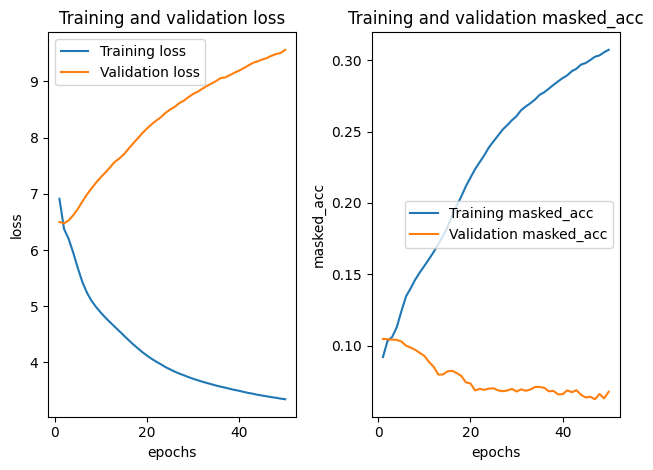

```
best_epoch is 2
```

```
122/122 ━━━━━━━━━━━━━━━━━━━━ 73s 540ms/step - loss: 7.6367 - masked_acc: 0.0827 - learning_rate: 0.0010
122/122 ━━━━━━━━━━━━━━━━━━━━ 67s 546ms/step - loss: 6.3832 - masked_acc: 0.1033 - learning_rate: 0.0010
Saving to model/summarization_model_2024-08-24_01-58-33.keras
Successfully saved model to model/summarization_model_2024-08-24_01-58-33.keras
```

```python
LEARNING_RATE = 0.001
NUM_EPOCHS = 50
STEPS_PER_EPOCH = None
# ENCODER_SEQUENCE_LENGTH = 128 # 128: 75% covered. max is 803.
# DECODER_SEQUENCE_LENGTH = 64 # 32: 75% covered. max is 64
DECODER_SEQUENCE_LENGTH = 128
MASK_ZERO = False

optimizer = keras.optimizers.AdamW(
    learning_rate=LEARNING_RATE,
)

model, filepath, history = build_model(
    train_ds, validation_ds, test_ds,
    vectorization_layer=vectorization_layer,
    num_decoders=2,
    num_heads=6,
    dropout=0.35,
    transformer_intermediate_dim=512,
    normalize_first=False,
    layer_norm_epsilon=1e-5,
    decoder_sequence_length=DECODER_SEQUENCE_LENGTH,
    use_residual=True,
    vocab_size=VOCABULARY_SIZE,
    batch_size=128,
    embedding_dim=128,
    mask_zero=MASK_ZERO,
    optimizer=optimizer,
    epochs=NUM_EPOCHS,
    steps_per_epoch=STEPS_PER_EPOCH,
    callbacks=[reduce_lr_callbacks],
)
plot(history=history)

optimizer = keras.optimizers.AdamW(
    learning_rate=LEARNING_RATE,
)
best_epoch = max(np.argmin(history.history[f"val_loss"]), np.argmax(history.history[f"val_masked_acc"]))
best_epoch = best_epoch + 1
print("best_epoch is", best_epoch)
model, filepath, history = build_model(
    train_ds.concatenate(validation_ds), None, test_ds,
    vectorization_layer=vectorization_layer,
    num_decoders=2,
    num_heads=6,
    dropout=0.35,
    transformer_intermediate_dim=512,
    normalize_first=False,
    layer_norm_epsilon=1e-5,
    decoder_sequence_length=DECODER_SEQUENCE_LENGTH,
    use_residual=True,
    vocab_size=VOCABULARY_SIZE,
    batch_size=128,
    embedding_dim=128,
    mask_zero=MASK_ZERO,
    optimizer=optimizer,
    epochs=best_epoch,
    steps_per_epoch=STEPS_PER_EPOCH,
    callbacks=[reduce_lr_callbacks],
)
```

```python
_, _, tds = build_datasets(
    train_ds=train_ds,
    validation_ds=validation_ds,
    test_ds=test_ds,
    vectorization_layer=vectorization_layer,
    batch_size=128,
    decoder_sequence_length=DECODER_SEQUENCE_LENGTH,
)
model.evaluate(tds)
```

```
7/7 ━━━━━━━━━━━━━━━━━━━━ 6s 524ms/step - loss: 6.3571 - masked_acc: 0.1043
```

```
[6.377806663513184, 0.1033923551440239]
```

```python
model.summary()
```

[output not shown]

[output not shown]

```
 Total params: 14,118,407 (53.86 MB)
```

```
 Trainable params: 14,118,407 (53.86 MB)
```

```
 Non-trainable params: 0 (0.00 B)
```

```python
y_true, y_pred = predict_dataset(
    model=model,
    iterable_dataset=tfds.as_numpy(test_ds), # The length of the test dataset is 819.
    decoder_sequence_length=DECODER_SEQUENCE_LENGTH,
    use_post_processing=True,
)
rouge_1_score, rouge_2_score, rouge_l_score = calculate_rouge_score(
    y_true=y_true,
    y_pred=y_pred,
)
print(rouge_1_score)
print(rouge_2_score)
print(rouge_l_score)
```

```
2024-08-23 17:19:16.108315: I tensorflow/core/framework/local_rendezvous.cc:404] Local rendezvous is aborting with status: OUT_OF_RANGE: End of sequence
```

```
{'precision': <tf.Tensor: shape=(), dtype=float32, numpy=0.2886696>, 'recall': <tf.Tensor: shape=(), dtype=float32, numpy=0.16244727>, 'f1_score': <tf.Tensor: shape=(), dtype=float32, numpy=0.19125858>}
{'precision': <tf.Tensor: shape=(), dtype=float32, numpy=0.023654176>, 'recall': <tf.Tensor: shape=(), dtype=float32, numpy=0.014071658>, 'f1_score': <tf.Tensor: shape=(), dtype=float32, numpy=0.016325954>}
{'precision': <tf.Tensor: shape=(), dtype=float32, numpy=0.237914>, 'recall': <tf.Tensor: shape=(), dtype=float32, numpy=0.13651876>, 'f1_score': <tf.Tensor: shape=(), dtype=float32, numpy=0.15944013>}
```

```python
y_true[:5], y_pred[:5]
```

```
(["Hannah needs Betty's number but Amanda doesn't have it. She needs to contact Larry.",
  'Eric and Rob are going to watch a stand-up on youtube.',
  "Lenny can't decide which trousers to buy. Bob advised Lenny on that topic. Lenny goes with Bob's advice to pick the trousers that are of best quality.",
  'Emma will be home soon and she will let Will know.',
  "Jane is in Warsaw. Ollie and Jane has a party. Jane lost her calendar. They will get a lunch this week on Friday. Ollie accidentally called Jane and talked about whisky. Jane cancels lunch. They'll meet for a tea at 6 pm."],
 ['Hannah is hannah to the for the to...',
  "Eric is a with [ unk ].. Cooler 's......... They and......... Snowfalls...... And",
  'Lenny and a to a the.............. Drafted...',
  "The will jonah 's to going to for for for dinner tonight.. Will in... Thai...",
  'Ollie and to are going to to............ 21. There. Muffins. Fan..... Come. Forest...............'])
```

## BART Model

Since the Transformer encoder-decoder model has reached the performance limit, the pre-trained BART model is used for the summarization task. Specifically, the model has 6 to 12 Transformer encoders and decoders, connected as the following diagram represents the architecture (Figure 4.6). It is the same as the Transformer encoder-decoder model aside from the pre-training with the tasks mentioned in the Literature Review section.

[figure not shown]

Figure 4.6: BART Model Graph

### Prediction

Like the prediction of the Transformer encoder-decoder model, the model derives a word to make a sequence. However, the implementation is hidden, and it is possible to generate a summarized sentence just by using the `generate` method.

```python
def generate_text(
        model,
        input_text,
        max_length=64):
    """
    Generate summarized text
    :model: the trained BART model
    :input_text: the original text that is summarized
    :max_length: the length of the summarized text
    """
    output = model.generate(
        input_text,
        max_length=max_length
    )
    return output

def generate_prediction_result(
        bart_lm,
        ds,
        max_length=64):
    """
    Generate summarized text from the dataset
    :bart_lm: the trained BART model
    :ds: the dataset, which is mainly text set, that is summarized
    :max_length: the length of the summarized text
    """
    x = []
    y_true = []
    for row in ds:
        x.append(row["encoder_text"].numpy())
        y_true.append(row["decoder_text"].numpy())

    # The first call to XLA generally takes a bit longer
    # because the XLA contains overhead of compilation and optimization.
    _ = generate_text(
        bart_lm,
        "dummy",
        max_length=max_length
    )

    y_pred = generate_text(
        bart_lm,
        ds.map(lambda row: row["encoder_text"]).batch(8),
        max_length=max_length,
    )
    return x, y_true, y_pred

def calculate_rouge_score(y_true, y_pred):
    """
    Calculate the ROUGE scores
    :y_true: the ground truth value
    :y_pred: the generated summarized text
    :returns: ROUGE-1 score
    :returns: ROUGE-2 score
    :returns: ROUGE-L score
    """
    rouge_n = keras_nlp.metrics.RougeN(order=2)
    rouge_2_score = rouge_n(y_true, y_pred)
    rouge_n = keras_nlp.metrics.RougeN(order=1)
    rouge_1_score = rouge_n(y_true, y_pred)
    rouge_l = keras_nlp.metrics.RougeL()
    rouge_l_score = rouge_l(y_true, y_pred)
    return rouge_1_score, rouge_2_score, rouge_l_score
```

### Training

The `build_bart_model` method is defined with various arguments so that hyperparameters can be injected from outside. Hereby, the same method can be used for various hyperparameter tunings.

```python
class RougeEvaluator(keras.callbacks.Callback):
    """
    Callback to calculate ROUGE scores for every epoch
    """
    def __init__(
            self,
            dataset,
            max_length):
        """
        :dataset: dataset object that is used for ROUGE evaluation
        :max_length: the max length of the summarized text
        """
        self.dataset = dataset
        self.max_length = max_length

    def on_epoch_end(self, epoch, logs=None):
        _, y_true, y_pred = generate_prediction_result(
            bart_lm=self.model,
            ds=self.dataset,
            max_length=self.max_length
        )
        rouge_1_score, rouge_2_score, rouge_l_score = calculate_rouge_score(
            y_true=y_true,
            y_pred=y_pred
        )
        print(rouge_1_score)
        print(rouge_2_score)
        print(rouge_l_score)

def format_dataset_bart_seq2seq(row):
    """
    BART pre-trained model assumes that
    the encoder and decoder text key are "encoder_text" and "decoder_text", respectively.
    """
    return {
        "encoder_text": row["dialogue"],
        "decoder_text": row["summary"]
    }

def build_bart_model(
    training_data,
    validation_data,
    encoder_sequence_length=128,  # 128: 75% covered. max is 803.
    decoder_sequence_length=64,  # 32: 75% covered. max is 64
    learning_rate=5e-5,
    weight_decay=0.01,
    epsilon=1e-6,
    global_clipnorm=1.0,
    batch_size=8,
    epochs=5,
    preset_name="bart_base_en",
    verbose=1,
    is_saved=False):
    """
    Build the BART model with specified parameters.
    :return: model: trained BART model
    :return: filepath: model file path if it is saved
    :return: history: history object to plot
    """
    now = datetime.datetime.now()
    preprocessor = keras_nlp.models.BartSeq2SeqLMPreprocessor.from_preset(
        preset_name,
        encoder_sequence_length=encoder_sequence_length,
        decoder_sequence_length=decoder_sequence_length,
    )
    bart_lm = keras_nlp.models.BartSeq2SeqLM.from_preset(
        preset_name,
        preprocessor=preprocessor
    )
    callbacks = []
    # if verbose > 0:
    #     bart_lm.summary()
    #     if validation_data is not None and not is_running_on_apple_silicon():
    #         callbacks.append(RougeEvaluator(
    #             dataset=validation_data.map(format_dataset_bart_seq2seq),
    #             max_length=decoder_sequence_length,
    #         ))

    optimizer = keras.optimizers.AdamW(
        learning_rate=learning_rate,
        weight_decay=weight_decay,
        epsilon=epsilon,
        global_clipnorm=global_clipnorm,
    )

    # Exclude layernorm terms and bias terms from weight decay.
    optimizer.exclude_from_weight_decay(var_names=[
        "bias",
        "gamma",
        "beta",
    ])

    bart_lm.compile(
        optimizer=optimizer,
        loss=keras.losses.SparseCategoricalCrossentropy(from_logits=True),
        weighted_metrics=[
            "accuracy"
        ],
    )
    val_ds = None
    if validation_data is not None:
        val_ds = validation_data.map(format_dataset_bart_seq2seq).batch(batch_size).cache()
    callbacks.append(get_tensorboard_callback(now=now))
    history = bart_lm.fit(
        training_data.map(format_dataset_bart_seq2seq).batch(batch_size).cache(),
        validation_data=val_ds,
        epochs=epochs,
        verbose=verbose,
        callbacks=callbacks,
    )

    filepath = None
    if is_saved:
        timestamp = now.strftime('%Y-%m-%d_%H-%M-%S')
        if is_running_on_apple_silicon() or is_running_on_intel_mac():
            filepath = f'model/summarization_bart_model_{timestamp}.keras'
        else:
            filepath = f'summarization_bart_model_{timestamp}.keras'
        print(f"Saving to {filepath}")
        bart_lm.save(filepath=filepath)
        print(f"Successfully saved model to {filepath}")

    return bart_lm, filepath, history
```

### Build

The best model is built with the hyperparameter set, which is derived by the experiments.

```python
train_ds, validation_ds, test_ds = prepare_datasets()
```

```
Downloading from https://www.kaggle.com/api/v1/models/keras/bart/keras/bart_large_en_cnn/2/download/metadata.json...
```

```
Downloading from https://www.kaggle.com/api/v1/models/keras/bart/keras/bart_large_en_cnn/2/download/tokenizer.json...
```

```
Downloading from https://www.kaggle.com/api/v1/models/keras/bart/keras/bart_large_en_cnn/2/download/assets/tokenizer/vocabulary.json...
```

```
Downloading from https://www.kaggle.com/api/v1/models/keras/bart/keras/bart_large_en_cnn/2/download/assets/tokenizer/merges.txt...
```

```
Downloading from https://www.kaggle.com/api/v1/models/keras/bart/keras/bart_large_en_cnn/2/download/config.json...
```

```
Downloading from https://www.kaggle.com/api/v1/models/keras/bart/keras/bart_large_en_cnn/2/download/model.weights.h5...
```

[output not shown]

```
1841/1842 ━━━━━━━━━━━━━━━━━━━━ 0s 120ms/step - accuracy: 0.5834 - loss: 0.7773
```

[output not shown]

```
1842/1842 ━━━━━━━━━━━━━━━━━━━━ 0s 358ms/step - accuracy: 0.5834 - loss: 0.7772
```

[output not shown]

```
1842/1842 ━━━━━━━━━━━━━━━━━━━━ 1277s 399ms/step - accuracy: 0.5834 - loss: 0.7772 - val_accuracy: 0.5857 - val_loss: 0.6998
1842/1842 ━━━━━━━━━━━━━━━━━━━━ 0s 118ms/step - accuracy: 0.6198 - loss: 0.6732
```

```
2024-08-21 11:24:28.217813: W external/local_tsl/tsl/framework/cpu_allocator_impl.cc:83] Allocation of 12352880640 exceeds 10% of free system memory.
2024-08-21 11:25:02.060982: W external/local_tsl/tsl/framework/cpu_allocator_impl.cc:83] Allocation of 12352880640 exceeds 10% of free system memory.
```

```
1842/1842 ━━━━━━━━━━━━━━━━━━━━ 268s 144ms/step - accuracy: 0.6198 - loss: 0.6732 - val_accuracy: 0.5899 - val_loss: 0.6939
1842/1842 ━━━━━━━━━━━━━━━━━━━━ 0s 118ms/step - accuracy: 0.6410 - loss: 0.6203
```

```
2024-08-21 11:28:56.868012: W external/local_tsl/tsl/framework/cpu_allocator_impl.cc:83] Allocation of 12352880640 exceeds 10% of free system memory.
```

```
1842/1842 ━━━━━━━━━━━━━━━━━━━━ 268s 144ms/step - accuracy: 0.6410 - loss: 0.6203 - val_accuracy: 0.5934 - val_loss: 0.6923
1842/1842 ━━━━━━━━━━━━━━━━━━━━ 268s 144ms/step - accuracy: 0.6606 - loss: 0.5753 - val_accuracy: 0.5924 - val_loss: 0.6930
1842/1842 ━━━━━━━━━━━━━━━━━━━━ 268s 144ms/step - accuracy: 0.6776 - loss: 0.5347 - val_accuracy: 0.5871 - val_loss: 0.7110
1842/1842 ━━━━━━━━━━━━━━━━━━━━ 272s 146ms/step - accuracy: 0.6960 - loss: 0.4957 - val_accuracy: 0.5850 - val_loss: 0.7244
1842/1842 ━━━━━━━━━━━━━━━━━━━━ 267s 144ms/step - accuracy: 0.7122 - loss: 0.4618 - val_accuracy: 0.5807 - val_loss: 0.7409
1842/1842 ━━━━━━━━━━━━━━━━━━━━ 273s 147ms/step - accuracy: 0.7284 - loss: 0.4275 - val_accuracy: 0.5804 - val_loss: 0.7644
1842/1842 ━━━━━━━━━━━━━━━━━━━━ 274s 147ms/step - accuracy: 0.7445 - loss: 0.3950 - val_accuracy: 0.5759 - val_loss: 0.7929
1842/1842 ━━━━━━━━━━━━━━━━━━━━ 271s 146ms/step - accuracy: 0.7617 - loss: 0.3639 - val_accuracy: 0.5703 - val_loss: 0.8226
1842/1842 ━━━━━━━━━━━━━━━━━━━━ 268s 144ms/step - accuracy: 0.7773 - loss: 0.3355 - val_accuracy: 0.5685 - val_loss: 0.8466
1842/1842 ━━━━━━━━━━━━━━━━━━━━ 276s 148ms/step - accuracy: 0.7922 - loss: 0.3083 - val_accuracy: 0.5629 - val_loss: 0.8903
1842/1842 ━━━━━━━━━━━━━━━━━━━━ 272s 146ms/step - accuracy: 0.8078 - loss: 0.2827 - val_accuracy: 0.5626 - val_loss: 0.9212
1842/1842 ━━━━━━━━━━━━━━━━━━━━ 272s 147ms/step - accuracy: 0.8226 - loss: 0.2574 - val_accuracy: 0.5634 - val_loss: 0.9475
1842/1842 ━━━━━━━━━━━━━━━━━━━━ 273s 147ms/step - accuracy: 0.8369 - loss: 0.2352 - val_accuracy: 0.5609 - val_loss: 0.9841
1842/1842 ━━━━━━━━━━━━━━━━━━━━ 272s 146ms/step - accuracy: 0.8490 - loss: 0.2140 - val_accuracy: 0.5572 - val_loss: 1.0146
1842/1842 ━━━━━━━━━━━━━━━━━━━━ 268s 144ms/step - accuracy: 0.8612 - loss: 0.1955 - val_accuracy: 0.5583 - val_loss: 1.0351
1842/1842 ━━━━━━━━━━━━━━━━━━━━ 274s 147ms/step - accuracy: 0.8726 - loss: 0.1772 - val_accuracy: 0.5565 - val_loss: 1.0815
1842/1842 ━━━━━━━━━━━━━━━━━━━━ 272s 146ms/step - accuracy: 0.8843 - loss: 0.1611 - val_accuracy: 0.5527 - val_loss: 1.1229
1842/1842 ━━━━━━━━━━━━━━━━━━━━ 268s 144ms/step - accuracy: 0.8956 - loss: 0.1447 - val_accuracy: 0.5506 - val_loss: 1.1535
0.692338764667511 The best number of epocs for the validation loss is 3
0.5933619141578674 The best number of epocs for the validation accuracy is 3
```

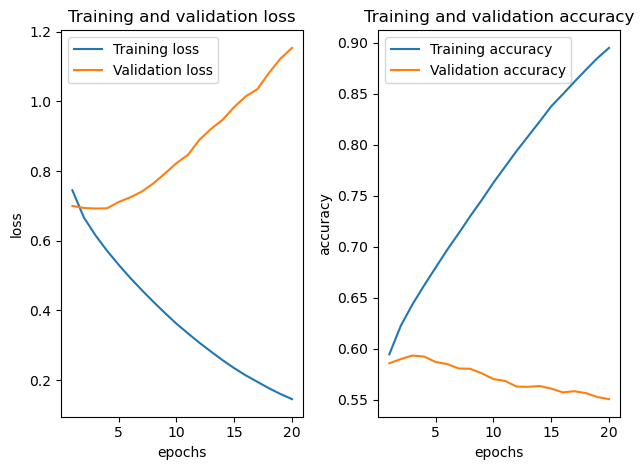

```
The best epoch is 3
```

[output not shown]

```
{'precision': <tf.Tensor: shape=(), dtype=float32, numpy=0.4574211>, 'recall': <tf.Tensor: shape=(), dtype=float32, numpy=0.4634792>, 'f1_score': <tf.Tensor: shape=(), dtype=float32, numpy=0.4315468>}
{'precision': <tf.Tensor: shape=(), dtype=float32, numpy=0.1917891>, 'recall': <tf.Tensor: shape=(), dtype=float32, numpy=0.19581003>, 'f1_score': <tf.Tensor: shape=(), dtype=float32, numpy=0.17995113>}
{'precision': <tf.Tensor: shape=(), dtype=float32, numpy=0.36424994>, 'recall': <tf.Tensor: shape=(), dtype=float32, numpy=0.3697562>, 'f1_score': <tf.Tensor: shape=(), dtype=float32, numpy=0.3434561>}
```

```python
bart_lm, filepath, history = build_bart_model(
    training_data=train_ds,
    validation_data=validation_ds,
    learning_rate=5e-6,
    batch_size=8,
    epochs=20,
    preset_name="bart_large_en_cnn",
    is_saved=False,
)
plot(history=history, keys=["loss", "accuracy"])

best_epoch = max(
    np.argmin(history.history[f"val_loss"]),
    np.argmax(history.history[f"val_accuracy"])
)
best_epoch = best_epoch + 1
print("The best epoch is", best_epoch)
bart_lm, filepath, _ = build_bart_model(
    training_data=train_ds.concatenate(validation_ds),
    validation_data=None,
    learning_rate=5e-6,
    batch_size=8,
    epochs=best_epoch,
    preset_name="bart_large_en_cnn",
    verbose=0,
    is_saved=True,
)
dialogue, y_true, y_pred = generate_prediction_result(
    bart_lm=bart_lm,
    ds=test_ds.map(format_dataset_bart_seq2seq),
)
rouge_1_score, rouge_2_score, rouge_l_score = calculate_rouge_score(
    y_true=y_true,
    y_pred=y_pred
)
print(rouge_1_score)
print(rouge_2_score)
print(rouge_l_score)
```

```python
model.evaluate(test_ds.map(format_dataset_bart_seq2seq))
```

[output not shown]

```python
bart_lm.summary()
```

```
Preprocessor: "bart_seq2_seq_lm_preprocessor_1"
```

```
┏━━━━━━━━━━━━━━━━━━━━━━━━━━━━━━━━━━━━━━━━━━━━━━━━━━━━┳━━━━━━━━━━━━━━━━━━━━━━━━━━━━━━━━━━━━━━━━━━━━━━━━━━━━━┓
┃ Tokenizer (type)                                   ┃                                             Vocab # ┃
┡━━━━━━━━━━━━━━━━━━━━━━━━━━━━━━━━━━━━━━━━━━━━━━━━━━━━╇━━━━━━━━━━━━━━━━━━━━━━━━━━━━━━━━━━━━━━━━━━━━━━━━━━━━━┩
│ bart_tokenizer (BartTokenizer)                     │                                              50,265 │
└────────────────────────────────────────────────────┴─────────────────────────────────────────────────────┘
```

```
Model: "bart_seq2_seq_lm_1"
```

```
┏━━━━━━━━━━━━━━━━━━━━━━━━━━━━━━━┳━━━━━━━━━━━━━━━━━━━━━━━━━━━┳━━━━━━━━━━━━━━━━━┳━━━━━━━━━━━━━━━━━━━━━━━━━━━━┓
┃ Layer (type)                  ┃ Output Shape              ┃         Param # ┃ Connected to               ┃
┡━━━━━━━━━━━━━━━━━━━━━━━━━━━━━━━╇━━━━━━━━━━━━━━━━━━━━━━━━━━━╇━━━━━━━━━━━━━━━━━╇━━━━━━━━━━━━━━━━━━━━━━━━━━━━┩
│ decoder_padding_mask          │ (None, None)              │               0 │ -                          │
│ (InputLayer)                  │                           │                 │                            │
├───────────────────────────────┼───────────────────────────┼─────────────────┼────────────────────────────┤
│ decoder_token_ids             │ (None, None)              │               0 │ -                          │
│ (InputLayer)                  │                           │                 │                            │
├───────────────────────────────┼───────────────────────────┼─────────────────┼────────────────────────────┤
│ encoder_padding_mask          │ (None, None)              │               0 │ -                          │
│ (InputLayer)                  │                           │                 │                            │
├───────────────────────────────┼───────────────────────────┼─────────────────┼────────────────────────────┤
│ encoder_token_ids             │ (None, None)              │               0 │ -                          │
│ (InputLayer)                  │                           │                 │                            │
├───────────────────────────────┼───────────────────────────┼─────────────────┼────────────────────────────┤
│ bart_backbone (BartBackbone)  │ [(None, None, 1024),      │     406,286,336 │ decoder_padding_mask[0][0… │
│                               │ (None, None, 1024)]       │                 │ decoder_token_ids[0][0],   │
│                               │                           │                 │ encoder_padding_mask[0][0… │
│                               │                           │                 │ encoder_token_ids[0][0]    │
├───────────────────────────────┼───────────────────────────┼─────────────────┼────────────────────────────┤
│ token_embedding               │ (None, None, 50264)       │      51,470,336 │ bart_backbone[0][0]        │
│ (ReversibleEmbedding)         │                           │                 │                            │
└───────────────────────────────┴───────────────────────────┴─────────────────┴────────────────────────────┘
```

```
 Total params: 1,218,859,014 (4.54 GB)
```

```
 Trainable params: 406,286,336 (1.51 GB)
```

```
 Non-trainable params: 0 (0.00 B)
```

```
 Optimizer params: 812,572,678 (3.03 GB)
```

```python
start = time.time()
dialogue, y_true, y_pred = generate_prediction_result(
    bart_lm=bart_lm,
    ds=test_ds.map(format_dataset_bart_seq2seq),
)
print(time.time() - start)
y_true[:5], y_pred[:5]
```

```
2024-08-21 13:23:10.201493: W tensorflow/core/framework/local_rendezvous.cc:404] Local rendezvous is aborting with status: OUT_OF_RANGE: End of sequence
2024-08-21 13:23:41.195739: W tensorflow/core/framework/local_rendezvous.cc:404] Local rendezvous is aborting with status: OUT_OF_RANGE: End of sequence
```

```
34.02424478530884
```

```
([b"Hannah needs Betty's number but Amanda doesn't have it. She needs to contact Larry.",
  b'Eric and Rob are going to watch a stand-up on youtube.',
  b"Lenny can't decide which trousers to buy. Bob advised Lenny on that topic. Lenny goes with Bob's advice to pick the trousers that are of best quality.",
  b'Emma will be home soon and she will let Will know.',
  b"Jane is in Warsaw. Ollie and Jane has a party. Jane lost her calendar. They will get a lunch this week on Friday. Ollie accidentally called Jane and talked about whisky. Jane cancels lunch. They'll meet for a tea at 6 pm."],
 ["Larry called Betty last time Amanda and Hannah were at the park together. Amanda will ask Larry to text Betty Betty's number to him.",
  "Eric and Rob are watching some Russian comedian's comedy. They think it's funny. They are going to watch more of him later tonight.",
  'Lenny needs to buy a pair of trousers, so Bob helps him to choose.',
  "Emma's not hungry for dinner tonight. She'll be home soon. Emma is not hungry for a drink.",
  'Ollie invited Jane for lunch on Friday, but Jane has a party the 18th. Ollie will call her to confirm.'])
```

```python
start = time.time()
tds = test_ds.map(format_dataset_bart_seq2seq)
x = []
y_true = []
y_pred = []
for row in tds:
    x.append(row["encoder_text"].numpy())
    y_true.append(row["decoder_text"].numpy())
    output = bart_lm.generate(
        row["encoder_text"].numpy().decode('UTF-8'),
        max_length=64,
    )
    y_pred.append(output)
print(time.time() - start)
y_true[:5], y_pred[:5]
```

```
240.53585004806519
```

```
2024-08-26 15:31:56.446611: W tensorflow/core/framework/local_rendezvous.cc:404] Local rendezvous is aborting with status: OUT_OF_RANGE: End of sequence
```

```
([b"Hannah needs Betty's number but Amanda doesn't have it. She needs to contact Larry.",
  b'Eric and Rob are going to watch a stand-up on youtube.',
  b"Lenny can't decide which trousers to buy. Bob advised Lenny on that topic. Lenny goes with Bob's advice to pick the trousers that are of best quality.",
  b'Emma will be home soon and she will let Will know.',
  b"Jane is in Warsaw. Ollie and Jane has a party. Jane lost her calendar. They will get a lunch this week on Friday. Ollie accidentally called Jane and talked about whisky. Jane cancels lunch. They'll meet for a tea at 6 pm."],
 ["Hannah asks Amanda for Betty's number. Amanda is not sure, so she tries to ask Larry. Larry called Betty last time they were at the park together. ",
  "Eric and Rob like the Russian comedian's stand-up.",
  'Lenny needs help choosing purple trousers for his job. Bob suggests him to get 2 pairs. ',
  'Emma will cook a vegetarian dinner tonight. She will be home soon. ',
  "Jane is in Warsaw. She's free for the 19th, but she can't have diner with Ollie on the 18th because there's a party. They are going to eat together on Friday."])
```

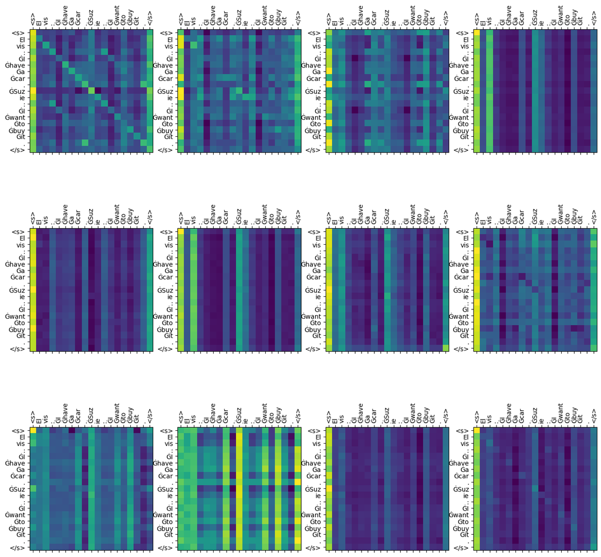

```python
visualize_bart_attention_scores(
    preprocessor=bart_lm.preprocessor,
    backbone=bart_lm.backbone,
    attention_layer=bart_lm.backbone.encoder_transformer_layers[0]._self_attention_layer,
    sentence="Elvis: I have a car. Suzie: I want to buy it.",
)
```

# Evaluation

## Performance Difference

[output not shown]

The BART model has drastically overcome other models. The baseline RNN and Transformer decoder-only models are useless due to their low quality.

Here, the reasons why the Transformer encoder-decoder model did not improve performance even though its architecture is almost identical to the BART model and it is experimented to have more heads, layers, units, and so on will be analyzed. The differences between the Transformer encoder-decoder model and the pre-trained BART model are visually recognizable as follows;

**Transformer Encoder-Decoder Model**

[figure not shown]

Figure 5.1: Visualized MultiHeadAttention for an example sentence "Elvis: I have a car. Suzie: I want to buy it." of the Transformer Encoder-Decoder Model

**BART Model**

[figure not shown]

Figure 5.2: Visualized MultiHeadAttention for an example sentence "Elvis: I have a car. Suzie: I want to buy it." of the BART Model

These are visualized weight scores of the first encoder layers in the Transformer encoder-decoder and the BART models. The former (Figure 5.1) well-represents the relationship between the word "car" in the first sentence and the word "buy" in the second sentence. However, all 6 attention heads resemble the others. That indicates 6 attentions captured similar features, even though they are expected to capture different features from text. Whereas all attentions in the BART model, which is represented in the latter one (Figure 5.2), have 12 significantly different and distinctive attentions. That is, in the BART model, the attention layers were able to capture various kinds of features. Most of them are caused by the pre-training phase. As a result, that made a difference in the amount of features and, finally, in the performance. That is one of the exciting and impressive points in the report.

## Hypothesis Verification

**Hyperparameter tunings are significantly effective even on a Transformer model.**

This is partially true. The number of epochs, such as classification and regression models, is still significant. The training must be stopped at the best epoch number to avoid overfitting. Otherwise, the model overfits the training data.

Moreover, the learning rate makes a remarkable difference in the training curve. When the learning rate `1e-3`, the same as the tuned Transformer encoder-decoder model, is used for fine-tuning the BART model, this phase does not improve the performance. It should be started with less than `1e-5`. That is, there must be an appropriate learning rate for each learning progress. Changing the learning rate on the way to training might improve performance a bit.

However, the most of other hyperparameters did not affect the performance unexpectedly and significantly.

**Pre-trained models improve the text summarization performance.**

**Transformer models can generate text more sophisticatedly than dense layer models.**

It did not turn out how to build a dense layer model that is comparable with the Transformer model for text summarization tasks.

Instead, an RNN sequence-to-sequence model, which was more practical, was used to build a text summarization model as the baseline model. This hypothesis was partially shown to be correct, comparing the Transformer encoder-decoder model with the RNN model. The Transformer encoder-decoder model was easily able to achieve a higher score. Note that the RNN model in this experiment is just for benchmarks, and it has not been well-tuned compared to the Transformer model. It is not always that the RNN model should not be used.

**The encoder-decoder model of the Transformer works better for text summarization tasks than the only-decoder model.**

This is partially true. In the case where their network is almost the same size without any pre-trained models, the encoder-decoder model is advantageous to the decoder-only models because the encoder-decoder model can use the whole original text from the encoder and all previous words from the decoder to predict the next word.

Moreover, the decoder-only models have a drawback where the input sequence length is the same as the output sequence length. It seems slightly inappropriate since the summarized text is mostly shorter than the input text.

The GPT model is one of the decoder-only architectures. Even though it might be possible to improve the performance in the case that the pre-trained model is used for this task, the experiment has not intentionally been executed so as not to deviate from the purpose of simply comparing with the Transformer encoder-decoder model.

**Optional investigation of RetNet**

It has not been executed due to the following reasons.

- Even though the comparative experiment with the Transformer model requires the highly optimized implementation, the stable implementation is only in PyTorch [30] and it is difficult to fairly compare the TensorFlow/Keras implementation.
- It is distant from the domain user's objective, which is the text summarization task. (It was more strongly focused on the personal interest.)

This was one of the shortcomings of this research plan. Therefore, it was deprioritized, and finally, the time was instead used to present the superiority of the Transformer model, compared to other models.

## Hyperparameters

Most of the best parameters have been identified experimentally. Not all combinations of hyperparameters are tested, but it is almost impossible to examine all combinations of hyperparameters. For example, no one knows whether there is a better value between empirically picked values on a numeric parameter than them. We rely on the assumption that it is supposed that it must be the best model after repeatedly choosing the better hyperparameters. And this is empirically true. Here are the hyperparameters that were identified in this report:

- The number of Transformer encoders
- The number of Transformer decoders
- The number of attention heads
- The dropout rate
- The dimensions of the Transformer intermediate layer
- Whether the normalization layer puts on a forward or backward
- The epsilon for normalization of the Transformer
- Whether the external residual connection is used
- The batch size
- The dimensions of the embedding
- The number of epochs

### Sequence length between the encoder and the decoder

The decoder sequence length was not compared because the loss value gets worse in the nature of the loss function regardless of the model performance if the length is shorter than the maximum length of the summarized text of the dataset. Although the encoder sequence length can be shortened to reduce memory consumption, the features are clearly lost from the dataset text.

## Model Size

[output not shown]

The same amount as each parameter size consumes the memory on the device. In the case where the summarization model runs on a server, any models above can run smoothly. Therefore, if there is not the restriction, the large BART model should be chosen due to its performance. If the other programs consume the memory, it might be better for the smaller BART model to run on the server. Finally, the Transformer encoder-decoder model should be chosen if the model runs on any mobile device. Only some high-end devices can currently run the 2.79 GB BART model.

Note that the greater the number of parameters, the more time it takes to load. In the case the prediction process is launched every time, larger models take longer time to launch and get ready for the prediction.

## Training Time

**NVIDIA V100 GPU**

| Model | step | epoch | training |
| --- | --- | --- | --- |
| Transformer encoder-decoder | 120ms (batch size 128) | 14s (122 steps) | 700s (50epochs) |
| BART | 144ms (batch size 8) | 273s (1842 steps) | 5460s (20epochs) |

**Apple Silicon M2**

| Model | step | epoch | training |
| --- | --- | --- | --- |
| RNN (Baseline) | 1s (batch size 128) | 130s (122 steps) | 6500s (50epochs) |
| Transformer encoder-decoder | 434ms (batch size 128) | 50s (122 steps) | 2500s (50epochs) |

The training of the Transformer encoder-decoder model was 2.6 times faster than the baseline RNN model, even though the baseline model had fewer layers and no attention mechanisms. That proved Transformer architecture is prior in the aspect of training parallelization.

The training of the BART model took 8 times longer time. It must be considered especially in the case where the code runs on a paid-per-hours environment such as AWS SageMaker. If the model requires many hyperparameter tunings, that will be a point of concern. If the BART model required many executions of the training phase, that would have been one of the obstacles.

## Prediction Time

| Model | NVIDIA V100 GPU | Apple Silicon M2 |
| --- | --- | --- |
| Transformer encoder-decoder | ※2459s | ※599s |
| BART | 241s | - |

※ Note that this is not a fair comparison for the following reasons.

The time values are for 819 dialogues from the text dataset. It is hard to process the prediction in parallel due to computational resource bottleneck (not I/O bottleneck). So, if the Transformer encoder-decoder model is run on the actual environment, it must be well-tuned like the BART model.

# Conclusion

Up to here, I have revealed the effectiveness of the Transformer model for the text summarization task and derived the best model practically and experimentally.

Even though the baseline RNN model might be improved with attention mechanisms, there is still a problem where the training time is more than 2.6 times longer. Moreover, the RNN model consumed RAM 4 times more than the Transformer encoder-decoder model in the local environment. Those were the advantages of the Transformer model shown in this project.

The Transformer encoder-decoder model was trained only with the dataset that I have downloaded. Even though the various hyperparameter tunings were executed for this model, the loss value only got slightly smaller, and the accuracy value only got slightly larger. The BART model, which was pre-trained with corpora, such as BooksCorpus, English Wikipedia, and CommonCrawl [28], was fine-tuned with the dataset I downloaded. This BART model easily overwhelmed the Transformer encoder-decoder model.

That indicates the effectiveness and necessity of the pre-training, which is based on transfer learning. In other words, the model with the fundamental comprehension for the whole language, English in this case, is effective for the text summarization task. Meanwhile, the model without language comprehension is easily overfitted because the dataset is everything for the model, and the model does not have linguistic knowledge at all. As a result, it was problematic from the aspect of the generalization performance.

## Future Research

This time, only the greedy search algorithm, where the most probable tokens were selected to construct, was used to decode a prediction result into a sentence. The comparison of the decoding methods was not executed. For example, if the beam search algorithm, where some of the more probable sequences at each time step are internally held and the best next token is predicted from them, was used, there would have been room to improve the quality of the predicted sequences.

Additionally, if the implementation supported the visualization of all other `MultiHeadAttention` layers in a Transformer model, the `MultiHeadAttention` of the first `TransformerDecoder` could have represented which words in a dialog correspond to words in the summary. That would be the beneficial information for the report.

Furthermore, the Transformer architecture is not perfect. The computational complexity of the self-attention mechanism is $O(n^2)$. A 2 times longer input sequence uses 4 times larger memory consumption. More advanced architectures are required to solve this problem.

Finally, the ROUGE score was used to measure the summarized text quality in this report. However, they are n-gram-based metrics, and it is not always that the text that marked a higher ROUGE score corresponds to the text human readers recognize better summarization, though the metrics and the feeling are correlated. There might be a better unknown way.

## Reflecting on the Development Process

It took a lot of time to identify the following problems in the development process:

1. The loss value is higher, and the accuracy value is lower than expected.
2. The training speed is slower than expected.

When a lower performance than expected was marked, it was difficult to logically identify whether the reason was the limitation of the model architecture or unknown bugs. As a result, code reviews were repeated with the suspicion that there should be bugs causing the low performance. In this time-consuming process, some minor bugs were fixed. For example, one of the bugs caused the transformations of tensors to be wrong, where the end Out Of Vocabulary (OOV) tags were added incorrectly. However, they were not so impactful to its performance. Eventually, that was only the upper limit of the model.

Moreover, the speed at which the training and predicting run is known only empirically.

| _ | NVIDIA V100 GPU x 1 | Mac Apple Silicon M2 | Mac Intel |
| --- | --- | --- | --- |
| 1 step time | 3~10 times faster | 1 | 10 times slower |
| RAM | 16 GB GPU memory | 32 GB | 32 GB |
| tensorflow-text/BART | o | partially works | o |

The Mac Apple Silicon M2 was mainly used as the development machine. The `tensorflow-metal` was used to accelerate it. However, the NVIDIA V100 GPU environment is at least 3 to 10 times faster. Especially when the RAM of the Mac is not enough for calculations, that makes a lot of swaps and at least 3 times slower than usual. The old Intel Mac was 10 times slower than the M2 Mac and useless, as shown in the above table.

Whereas, when the tensor data overflowed from the NVIDIA V100 16GB GPU memory, the training program was killed by the Out-Of-Memory error (OOM). That is, it must calculate only within 16GB.

In this research, the KerasNLP library was used, and some classes were dependent on the `tensorflow-text` library. When the research started, the `tensorflow-text` library did not support Apple Silicon Mac, and the situation did not change until July 2024. Even though it started supporting, the BART model does not work yet.

## Ethical Consideration

In the experiments of this research, critical problems with the dataset biases did not emerge. However, all datasets contain biases, which might be problematic. For example, the paper "The Unequal Opportunities of Large Language Models: Revealing Demographic Bias through Job Recommendations" [27] reveals the inequality of Large Language Models (LLM) on job recommendations as follows:

> We demonstrate the mere mention of nationality or gender identity can significantly skew results, and developers should be hyper-aware of introducing biases into the system. If demographic attributes are necessary, developers should critically evaluate how to incorporate this information fairly and conduct experiments to understand and address biases. [27]

Just in terms of the controllability of the models, the Transformer encoder-decoder model holds the advantage over the pre-trained BART model because the problematic entries can be excluded from the training dataset or be weakened from the perspective of the whole model. Therefore, the best practice will be for the BART model to run and for the Transformer encoder-decoder model to be prepared as a backup plan for a problematic situation.

# References

- [1] Vaswani et al. (2017). Attention Is All You Need.https://doi.org/10.48550/arXiv.1706.03762
- [2] tensorflow. Tensor2tensor. Retrieved May 16, 2024, from https://github.com/tensorflow/tensor2tensor
- [3] Yutao et al. (2023). Retentive Network: A Successor to Transformer for Large Language Models. https://doi.org/10.48550/arXiv.2307.08621
- [4] Wojciech et al. (2019). Neural Text Summarization: A Critical Evaluation. https://doi.org/10.48550/arXiv.1908.08960
- [5] Yang et al. (2019). Text Summarization with Pretrained Encoders. https://doi.org/10.48550/arXiv.1908.08345
- [6] Chollet, F. (2021). *Deep Learning with Python* (2nd ed., p. 266). Manning.
- [7] Chollet, F. (2021). *Deep Learning with Python* (2nd ed., p. 246). Manning.
- [8] Chin-Yew Lin. 2004. ROUGE: A Package for Automatic Evaluation of Summaries. In Text Summarization Branches Out, pages 74–81, Barcelona, Spain. Association for Computational Linguistics. https://aclanthology.org/W04-1013/
- [9] Dosovitskiy, A. (2021). An Image is Worth 16x16 Words: Transformers for Image Recognition at Scale. https://doi.org/10.48550/arXiv.2010.11929
- [10] Devlin, J. (2018). BERT: Pre-training of Deep Bidirectional Transformers for Language Understanding. https://doi.org/10.48550/arXiv.1810.04805
- [11] Chollet, F. (2021). *Deep Learning with Python* (2nd ed., p. 250). Manning.
- [12] TensorFlow. Retrieved June 6, 2024, from https://www.tensorflow.org
- [13] Keras: Deep Learning for humans. https://keras.io/
- [14] KerasNLP. Retrieved June 6, 2024, from https://keras.io/keras_nlp/
- [15] PyTorch. (2024, May 10). https://pytorch.org/
- [16] Hugging Face, Inc. Transformers. Retrieved June 6, 2024, from https://github.com/huggingface/transformers
- [17] (2020, February 22). facebook/bart-large-cnn. Retrieved May 1, 2024, from https://huggingface.co/facebook/bart-large-cnn
- [18] (2020, Aug 9). google/pegasus-cnn_dailymail. Retrieved May 1, 2024, from https://huggingface.co/google/pegasus-cnn_dailymail
- [19] facebook (2020, February 22). Facebook/bart-large-cnn. Retrieved June 10, 2024, from https://huggingface.co/facebook/bart-large-cnn
- [20] Google (2020, August 9). Google/pegasus-cnn_dailymail. Retrieved June 10, 2024, from https://huggingface.co/google/pegasus-cnn_dailymail
- [21] Zhang, J. (2020). PEGASUS: Pre-training with Extracted Gap-sentences for Abstractive Summarization. https://doi.org/10.48550/arXiv.1912.08777
- [22] Google (2023, July 8). Abstractive Text Summarization with BART. Retrieved June 10, 2024, from https://keras.io/examples/nlp/abstractive_summarization_with_bart/
- [23] Lewis, M. et al. (2019). BART: Denoising Sequence-to-Sequence Pre-training for Natural Language Generation, Translation, and Comprehension. https://doi.org/10.48550/arXiv.1910.13461
- [24] Chin-Yew Lin. (2004) ROUGE: A Package for Automatic Evaluation of Summaries. https://aclanthology.org/W04-1013/
- [25] Bogdan Gliwa. et al. (2019) SAMSum Corpus: A Human-annotated Dialogue Dataset for Abstractive Summarization https://doi.org/10.48550/arXiv.1911.12237
- [26] Datasets Catalog. Retrieved June 6, 2024, from https://www.tensorflow.org/datasets/catalog/overview
- [27] Abel Salinas. et al. (2023) The Unequal Opportunities of Large Language Models: Revealing Demographic Bias through Job Recommendations. https://doi.org/10.48550/arXiv.2308.02053
- [28] Google LLC. KerasNLP Models. Retrieved August 10, 2024, from https://keras.io/api/keras_nlp/models/
- [29] Chollet, F. (2024). *Deep Learning with Python* (2nd ed., p. 302). Manning.
- [30] Microsoft. torchscale. Retrieved September 8, 2024, from https://github.com/microsoft/torchscale

# Appendix

The hyperparameters for each model were derived throughout numerous experiments in this report. Their experiments were recorded in the following files of the GitHub repository.

| Model | File |
| --- | --- |
| RNN (Baseline Model) | appendix/summarization_base.ipynb |
| Transformer encoder-decoder | appendix/summarization_base_transformer.ipynb |
| Transformer decoder-only | appendix/summarization_decoder_transformer.ipynb |
| BART | appendix/summarization_bart.ipynb |